# Participation in the elections on the local level

Olga Lavrinenko

2023-03-25

```r
library(car)
library(dplyr)
library(effects)
library(foreign)
library(haven)
library(ISLR)
library(ggplot2)
library(gplots)
library(ggpubr)
library(lm.beta)
library(QuantPsyc)
library(readr)
library(rpart)
library(rpart.plot)
library(sjPlot)
library(tidyverse)
```

# I. Introduction – what’s your idea

Basically, electoral research **focuses on political technology aspects**: what factors in what way influence the choice of voters; what exactly is valued and ignored; what information do voters “peck” on; how to conduct election campaigns; how to conduct agitation and propaganda; what type (status, education, age, gender, work experience, pedigree) of a candidate is accepted by voters (Dangasurengiin O., Amarzhargalyn N. Political and psychological behavior of Mongolian voters, 2019).

At the same time, the question of what factors influence the **regular participation** of the voter in elections remains poorly covered. At the same time, knowledge of these factors may help develop a strategy to involve the population in the political process, increase voter turnout and achieve the most representative election results.

In this regard, the research question of this study is: “What factors increase the chances of regular participation in elections at the local level in Mongolia?”

# II. Data description

## What country you choose; how many cases are there.

**! Check that there is a variance in the answers for the outcome variable: if the majority of the individuals always attend the elections, it will be very hard to predict something. The best cases are those closer to 50/50 balance.**

Since the work requires a logical regression, the country was chosen according to the proportional distribution of answers to the question about participation in elections. In Mongolia, the distribution of responses by code book seems to be one of the most appropriate (52.3% for the “always” category and 47.7% for the other categories). Of course, after removing the missing values, the percentages may change, but at the same time, the initial distribution suggests that the balance will remain.

At the moment, the database with predictors consists of 1638 observations and 29 variables.

```r
# setwd("D:/Data Analytics For Politics And Society/Data analysis (2-3 modules)/Project 2")
WVS_EVS <- read_spss('ZA7505_v4-0-01.sav')

Mongolia_WVS_EVS <- WVS_EVS[WVS_EVS$cntry == 496,
                            c("cntry_AN", "E263", "X001", "X003R2", "X025A_01",
                              "F034", "X007", "A009", "A170", "X047_WVS7",
                              "A004", "E023", "E025", "E026", "E027", "E028",
                              "E037", "E069_07", "E069_11", "E069_01", "E069_02",
                              "E069_04", "E069_05", "E069_06", "E069_08", "E069_12",
                              "E069_13", "E069_14", "E069_17")]

dim(Mongolia_WVS_EVS)
```

```
## [1] 1638   29
```

```r
table(Mongolia_WVS_EVS$E263)
```

```
##
##   1   2   3   4
## 713 574 275  76
```

**! Regarding the missings: make sure you don’t lose many cases when getting rid of NA’s. Like, deleting half of the dataset is not a good idea. It’s better not to use predictors with many missing values.**

Mostly, the variables E069_ have missing values, but since we need them for factor analysis, I did not include in the subset only those that contain a distinctively large number of missing values.

After removing the missing values, we lost about 500 observations and we are left with 1134 rows.

```r
Mongolia_WVS_EVS <- na.omit(Mongolia_WVS_EVS)
dim(Mongolia_WVS_EVS)
```

```
## [1] 1134   29
```

# III. Hypotheses

1. **Gender** is likely not to affect the chances of regular participation in elections.
2. The **age** of 30-49 years is likely to increase the chances of regular participation in elections compared to the age of up to 30 years
3. Having a *tertiary education** is likely to increase the chances of regular participation in elections compared to secondary education and below
4. **Political interest** is likely to increase the chances of regular participation in elections
5. **Confidence in government** is likely to increase the chances of regular participating in elections
6. **Participation in boycotts** is likely to reduce the chances of regular participation in elections
7. **Joining unofficial strikes** is likely to reduce the chances of regular participation in elections

# IV. Analysis with the technical interpretation of the results

## 1. Preparation:

**1.1. Create a binary variable “participation in the elections”, dividing individuals into 2 categories: those who always participate in the elections and the others. Double-check that your final categories are close to balance.**

The balance shifted after removing the missing values, и the ratios between the categories became 39 % vs. 61%, but both categories are still saturated with observations.

```r
Mongolia_WVS_EVS$vote <- Mongolia_WVS_EVS$E263
table(Mongolia_WVS_EVS$vote)
```

```
##
##   1   2   3   4
## 445 444 197  48
```

```r
Mongolia_WVS_EVS$vote <- as.factor(ifelse(Mongolia_WVS_EVS$vote >= 2, 0, 1))
table(Mongolia_WVS_EVS$vote)
```

```
##
##   0   1
## 689 445
```

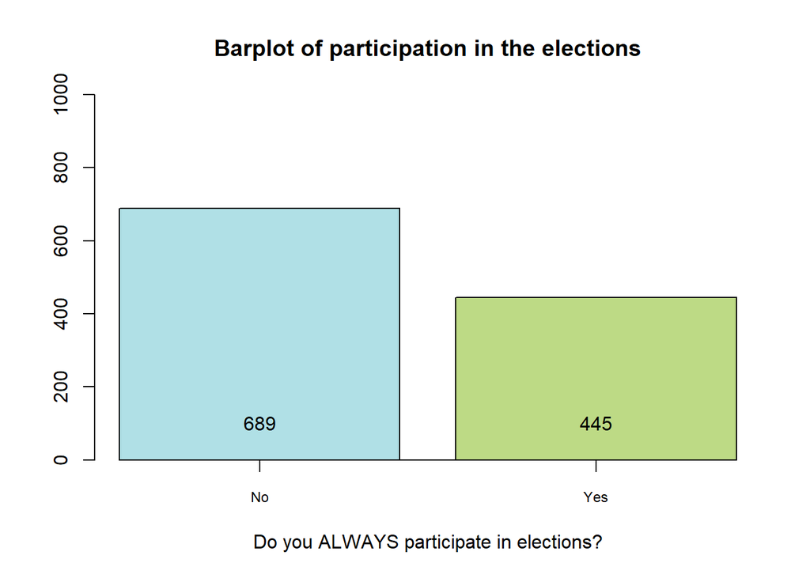

```r
bp_1 <- barplot(table(Mongolia_WVS_EVS$vote),
        beside = T,
        xlab = "Do you ALWAYS participate in elections?",
        ylim = c(0, 1000),
        xaxt = "n",
        main = "Barplot of participation in the elections",
        col = c("#B0E0E6", "#BDDA85"))

text(bp_1, 50, table(Mongolia_WVS_EVS$vote), col = "black", pos = 3)

axis(side = 1, at = bp_1[c(1:2)],
     labels = c("No", "Yes"),
     cex.axis = 0.75)
```

**1.2. Choose the predictors**

1. Socio-economic factors (8 predictors): gender (X001), age (X003R2), education (X025A_01), marital status (X007), religion (F034), health status (A009), life satisfaction (A170), income (X047_WVS7).
2. Political attitudes (5 predictors): political importance (A004), interest in politics (E023), government responsibilities (E037), confidence in government (E069_11), confidence in parliament (E069_07).
3. Political activity (4 predictors): signing a petition (E025), joining boycotts (E026), attending lawful/peaceful demonstrations (E027), joining unofficial strikes (E028).

**1.3. Discover the properties of your data. What can you say about the distributions? Character and number of missings? Recode everything that needs to be recoded. Specify the correct types of the variables.**

**1. Gender**: variable type is categorical, values are distributed evenly: 594 for “female” and 540 for “male”.

```r
table(Mongolia_WVS_EVS$X001)
```

```
##
##   1   2
## 540 594
```

```r
Mongolia_WVS_EVS$sex <- as.factor(ifelse(Mongolia_WVS_EVS$X001 == 1, "Male",
                                         "Female"))
table(Mongolia_WVS_EVS$sex)
```

```
##
## Female   Male
##    594    540
```

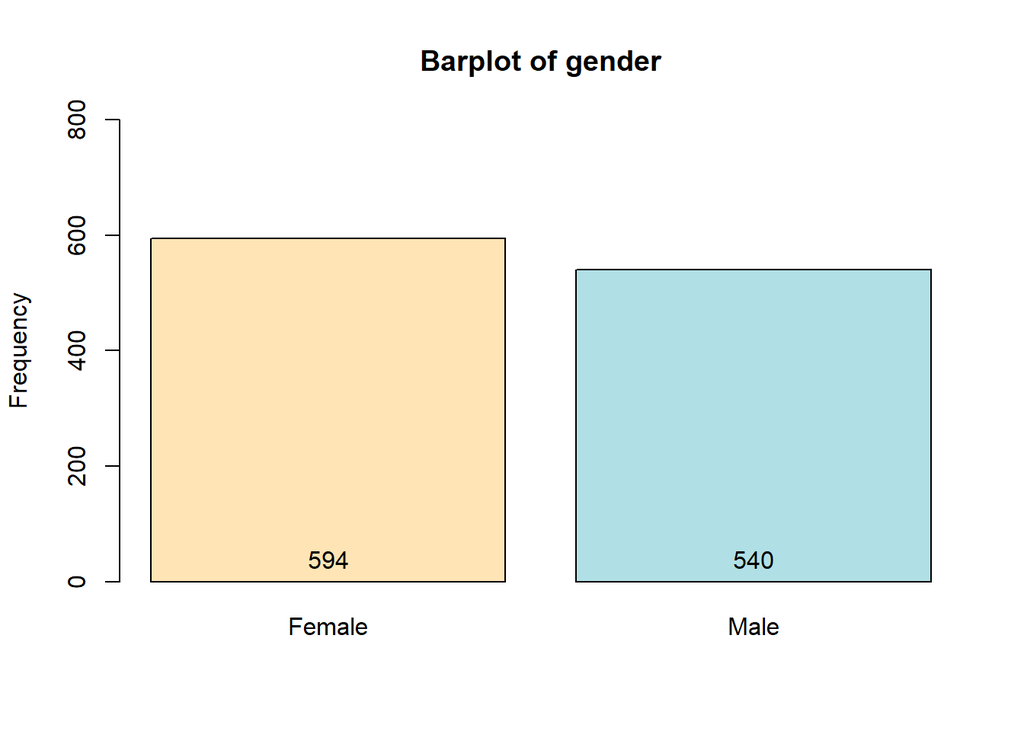

```r
bp_2 <- barplot(table(Mongolia_WVS_EVS$sex),
        beside = T,
        ylab = "Frequency",
        ylim = c(0, 800),
        main = "Barplot of gender",
        col = c("#FFE4B5", "#B0E0E6"))
text(bp_2, -1.4, table(Mongolia_WVS_EVS$sex), col = "black", pos = 3)
```

**2. Age**: variable type is categorical, values are distributed quite evenly.

```r
table(Mongolia_WVS_EVS$X003R2)
```

```
##
##   1   2   3
## 334 514 286
```

```r
Mongolia_WVS_EVS$age <- as.factor(ifelse(Mongolia_WVS_EVS$X003R2 == 1, "15 - 29",
                                  ifelse(Mongolia_WVS_EVS$X003R2 == 2, "30 - 49",
                                  "55 and more")))
table(Mongolia_WVS_EVS$age)
```

```
##
##     15 - 29     30 - 49 55 and more
##         334         514         286
```

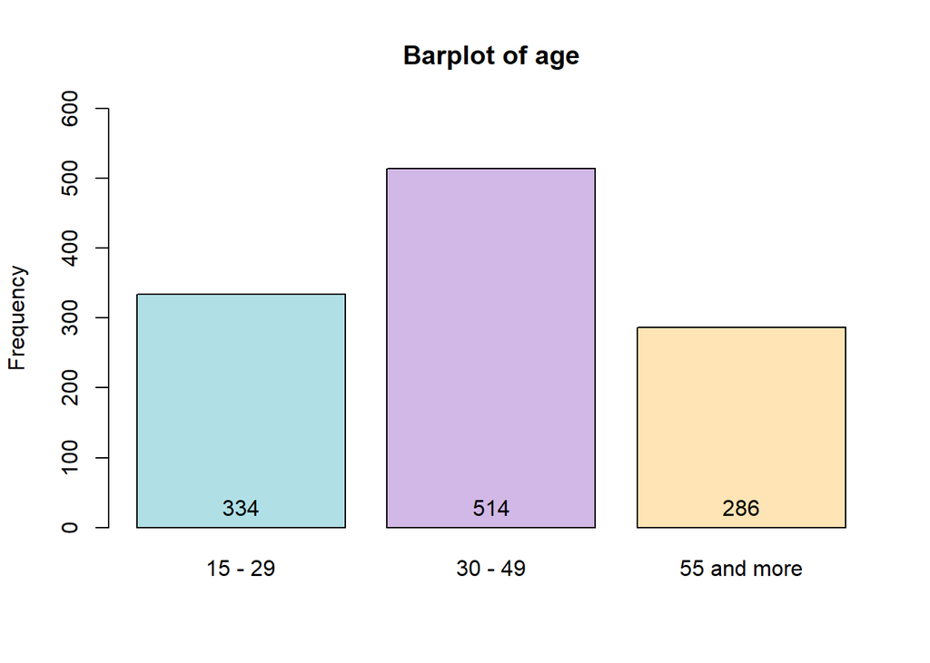

```r
bp_3 <- barplot(table(Mongolia_WVS_EVS$age),
        beside = T,
        ylab = "Frequency",
        ylim = c(0, 600),
        main = "Barplot of age",
        col = c("#B0E0E6", "#D1B8E6", "#FFE4B5"))

text(bp_3, -1.4, table(Mongolia_WVS_EVS$age), col = "black", pos = 3)
```

```r
table(Mongolia_WVS_EVS$X025A_01)
```

```
##
##   0   1   2   3   4   5   6   7   8
##   4  15  71 249 149  73 466 105   2
```

```r
Mongolia_WVS_EVS$education <- as.factor(ifelse(Mongolia_WVS_EVS$X025A_01 >= 5,
                                               "Tertiary education",
                                               "Secondary education or less"))
table(Mongolia_WVS_EVS$education)
```

```
##
## Secondary education or less          Tertiary education
##                         488                         646
```

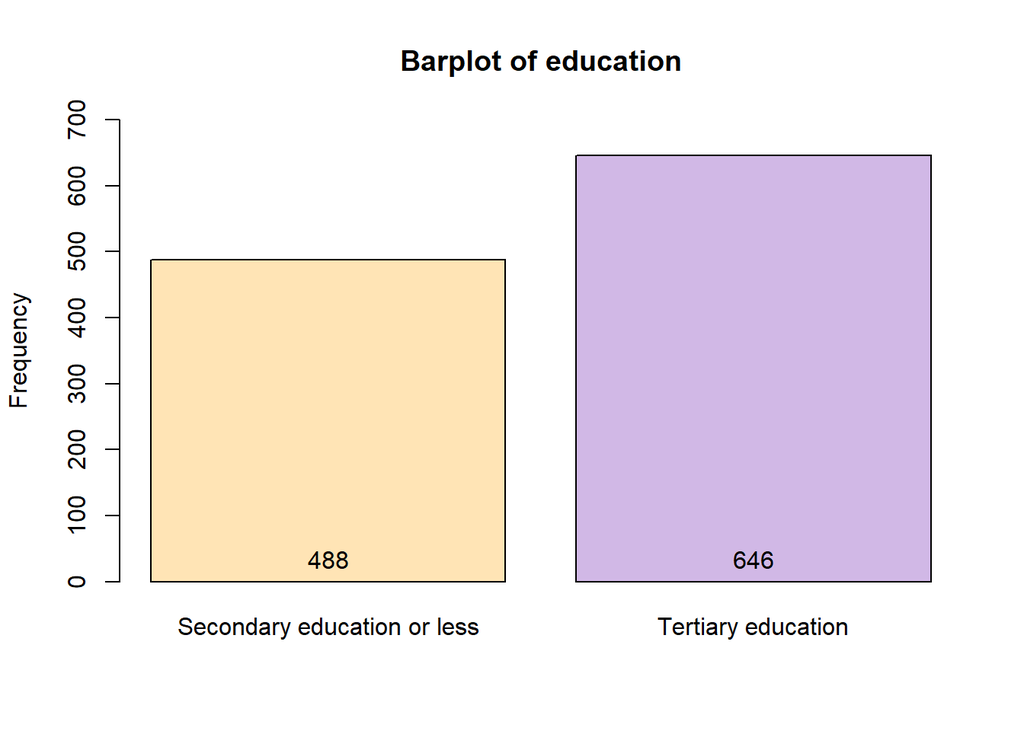

```r
bp_4 <- barplot(table(Mongolia_WVS_EVS$education),
        beside = T,
        ylab = "Frequency",
        ylim = c(0, 700),
        main = "Barplot of education",
        col = c("#FFE4B5", "#D1B8E6"))
text(bp_4, -1.4, table(Mongolia_WVS_EVS$education), col = "black", pos = 3)
```

**4. Marital status**: variable type is categorical, values are distributed unevenly: very few observations for categories 3 - 5, (at most 59 observations). Therefore, we need to recode: I decided to combine into three categories - married, living together as married, single.

```r
table(Mongolia_WVS_EVS$X007)
```

```
##
##   1   2   3   4   5   6
## 525 289  18  18  59 225
```

```r
Mongolia_WVS_EVS$marital_st <- as.factor(ifelse(Mongolia_WVS_EVS$X007 == 1,
                                                "Married",
                                         ifelse(Mongolia_WVS_EVS$X007 == 2,
                                                "Living together",
                                                "Single")))
table(Mongolia_WVS_EVS$marital_st)
```

```
##
## Living together         Married          Single
##             289             525             320
```

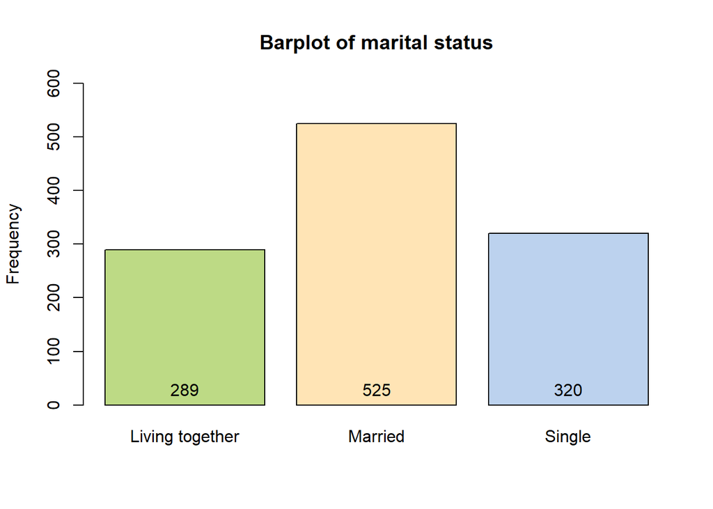

```r
bp_5 <- barplot(table(Mongolia_WVS_EVS$marital_st),
        beside = T,
        ylab = "Frequency",
        ylim = c(0, 600),
        main = "Barplot of marital status",
        col = c("#BDDA85", "#FFE4B5", "#BCD2EE"))
text(bp_5, -1.4, table(Mongolia_WVS_EVS$marital_st), col = "black", pos = 3)
```

**5. Religious status**: variable type is categorical, values are distributed unevenly: very few observations for category 3 (151 observations). Therefore, we need to recode: I decided to combine into two categories - religious person, not a religious person.

```r
table(Mongolia_WVS_EVS$F034)
```

```
##
##   1   2   3
## 422 561 151
```

```r
Mongolia_WVS_EVS$religion <- as.factor(ifelse(Mongolia_WVS_EVS$F034 == 1,
                                              "Religious person",
                                              "Not a religious person"))
table(Mongolia_WVS_EVS$religion)
```

```
##
## Not a religious person       Religious person
##                    712                    422
```

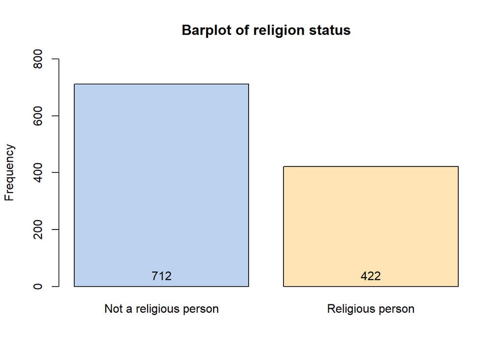

```r
bp_6 <- barplot(table(Mongolia_WVS_EVS$religion),
        beside = T,
        ylab = "Frequency",
        ylim = c(0, 800),
        main = "Barplot of religion status",
        col = c("#BCD2EE", "#FFE4B5"))
text(bp_6, -1.4, table(Mongolia_WVS_EVS$religion), col = "black", pos = 3)
```

**6. Health status**: variable type is categorical, values are distributed unevenly: very few observations for categories 1, 4, 5 (at most 179). Therefore, we need to recode: I decided to combine into two categories - good health and others - not so good health.

```r
table(Mongolia_WVS_EVS$A009)
```

```
##
##   1   2   3   4   5
## 179 487 297 156  15
```

```r
Mongolia_WVS_EVS$health <- as.factor(ifelse(Mongolia_WVS_EVS$A009 <= 2, "Good",
                                            "Not so good"))
table(Mongolia_WVS_EVS$health)
```

```
##
##        Good Not so good
##         666         468
```

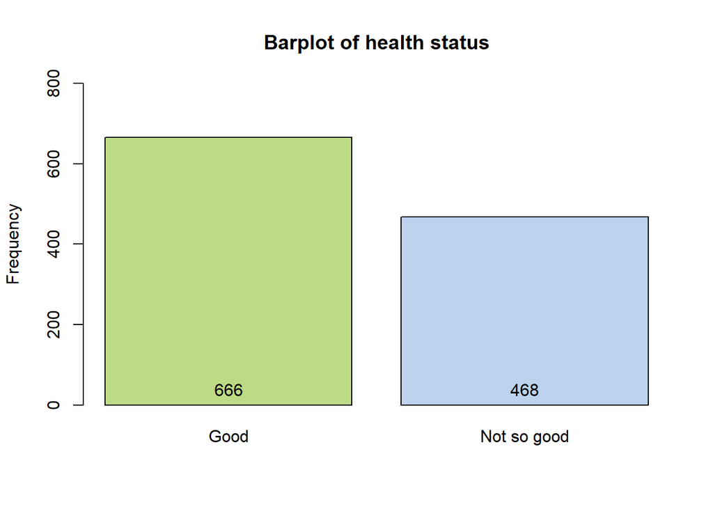

```r
bp_7 <- barplot(table(Mongolia_WVS_EVS$health),
        beside = T,
        ylab = "Frequency",
        ylim = c(0, 800),
        main = "Barplot of health status",
        col = c("#BDDA85", "#BCD2EE"))
text(bp_7, -1.4, table(Mongolia_WVS_EVS$health), col = "black", pos = 3)
```

**7. Life satisfaction**: variable type is numeric. Data is almost symmetrical and close to a normal distribution. Minimal value is 1, while maximum is 10, and mean is 6.4.

```r
Mongolia_WVS_EVS$life_sat <- as.numeric(Mongolia_WVS_EVS$A170)
summary(Mongolia_WVS_EVS$life_sat)
```

```
##    Min. 1st Qu.  Median    Mean 3rd Qu.    Max.
##   1.000   5.000   6.000   6.398   8.000  10.000
```

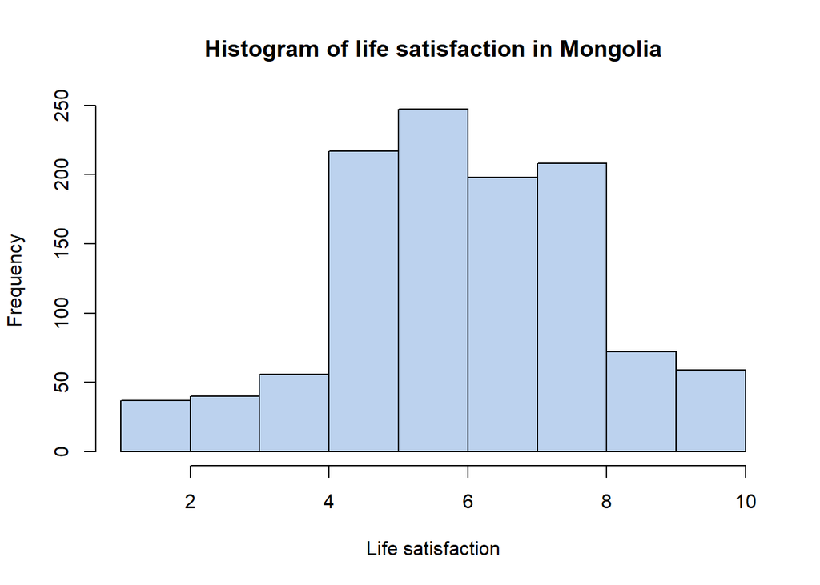

```r
hist(Mongolia_WVS_EVS$life_sat,
     main = "Histogram of life satisfaction in Mongolia",
     xlab = "Life satisfaction", col = "#BCD2EE",
     breaks = 10)
```

**8. Income**: variable type is numeric. Data is almost symmetrical and close to a normal distribution. Minimal value is 1, while maximum is 10, and mean is 5.5.

```r
Mongolia_WVS_EVS$income <- as.numeric(Mongolia_WVS_EVS$X047_WVS7)
summary(Mongolia_WVS_EVS$income)
```

```
##    Min. 1st Qu.  Median    Mean 3rd Qu.    Max.
##   1.000   5.000   6.000   5.536   7.000  10.000
```

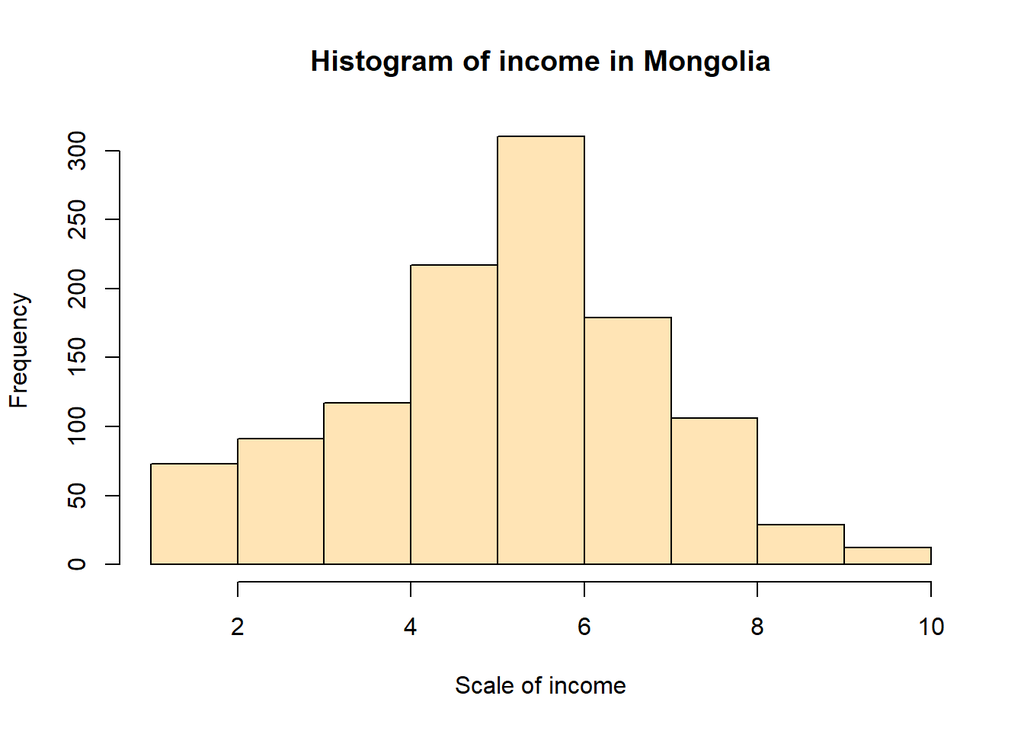

```r
hist(Mongolia_WVS_EVS$income,
     main = "Histogram of income in Mongolia",
     xlab = "Scale of income", col = "#FFE4B5",
     breaks = 10)
```

**9. Importance of politics**: variable type is categorical, values are distributed unevenly: very few observations for categories 1 and 4 (at most 156). Therefore, we need to recode: I decided to combine into two categories: important and not important.

```r
table(Mongolia_WVS_EVS$A004)
```

```
##
##   1   2   3   4
## 156 450 420 108
```

```r
Mongolia_WVS_EVS$pol_importance <- as.factor(ifelse(Mongolia_WVS_EVS$A004 <= 2,
                                                    "Important",
                                                    "Not important"))
table(Mongolia_WVS_EVS$pol_importance)
```

```
##
##     Important Not important
##           606           528
```

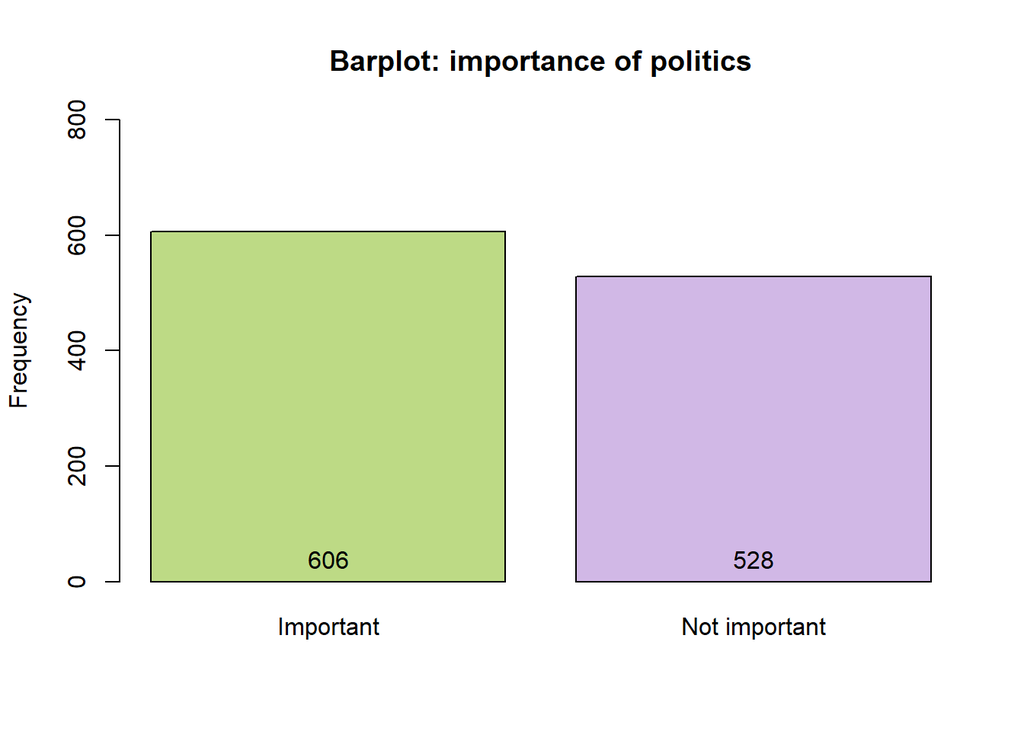

```r
bp_8 <- barplot(table(Mongolia_WVS_EVS$pol_importance),
        beside = T,
        ylab = "Frequency",
        ylim = c(0, 800),
        main = "Barplot: importance of politics",
        col = c("#BDDA85", "#D1B8E6"))
text(bp_8, -1.4, table(Mongolia_WVS_EVS$pol_importance), col = "black", pos = 3)
```

**10. Interest in politics**: variable type is categorical, values are distributed unevenly: very few observations for categories 1 and 4 (at most 172). Therefore, we need to recode: I decided to combine into two categories: interested and not interested.

```r
table(Mongolia_WVS_EVS$E023)
```

```
##
##   1   2   3   4
##  76 295 591 172
```

```r
Mongolia_WVS_EVS$pol_interest <- as.factor(ifelse(Mongolia_WVS_EVS$E023 <= 2,
                                                  "Interested",
                                                  "Not interested"))
table(Mongolia_WVS_EVS$pol_interest)
```

```
##
##     Interested Not interested
##            371            763
```

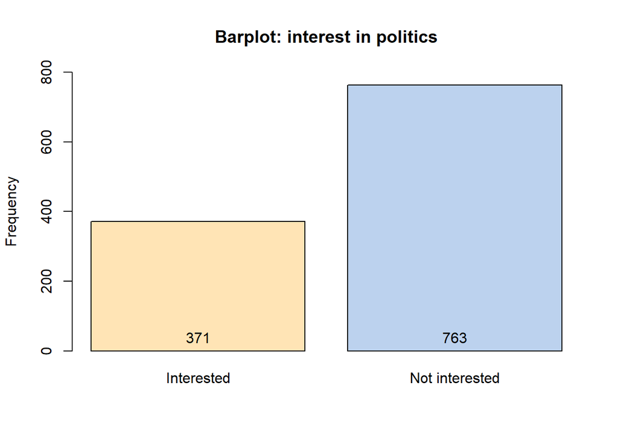

```r
bp_9 <- barplot(table(Mongolia_WVS_EVS$pol_interest),
        beside = T,
        ylab = "Frequency",
        ylim = c(0, 800),
        main = "Barplot: interest in politics",
        col = c("#FFE4B5", "#BCD2EE"))
text(bp_9, -1.4, table(Mongolia_WVS_EVS$pol_interest), col = "black", pos = 3)
```

**11. Government responsibility**: variable type is numeric. data is piled up on the left, so it’s right-skewed data. Minimal value is 1, while maximum is 10, and mean is 4.7.

```r
# from "People should take more responsibility" to
#      "The government should take more responsibility"

Mongolia_WVS_EVS$government_resp <- as.numeric(Mongolia_WVS_EVS$E037)
summary(Mongolia_WVS_EVS$government_resp)
```

```
##    Min. 1st Qu.  Median    Mean 3rd Qu.    Max.
##   1.000   3.000   5.000   4.681   6.000  10.000
```

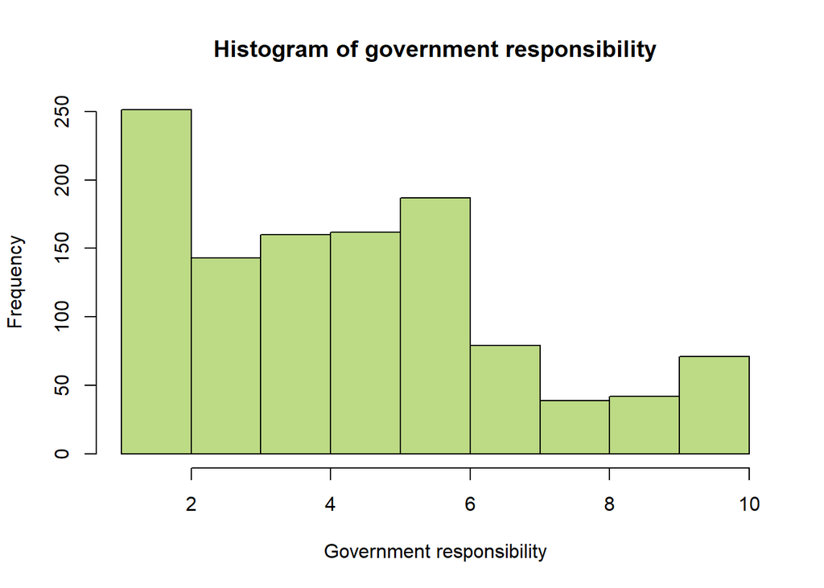

```r
hist(Mongolia_WVS_EVS$government_resp,
     main = "Histogram of government responsibility",
     xlab = "Government responsibility", col = "#BDDA85",
     breaks = 10)
```

**12. Confidence in government**: variable type is categorical, values are distributed unevenly: very few observations for category 1 (114 observations). Therefore, we need to recode: I decided to combine into two categories: confident and not confident.

```r
table(Mongolia_WVS_EVS$E069_11)
```

```
##
##   1   2   3   4
## 114 308 488 224
```

```r
Mongolia_WVS_EVS$government_conf <- as.factor(ifelse(Mongolia_WVS_EVS$E069_11 <= 2,
                                                     "Confident",
                                                     "Not confident"))
table(Mongolia_WVS_EVS$government_conf)
```

```
##
##     Confident Not confident
##           422           712
```

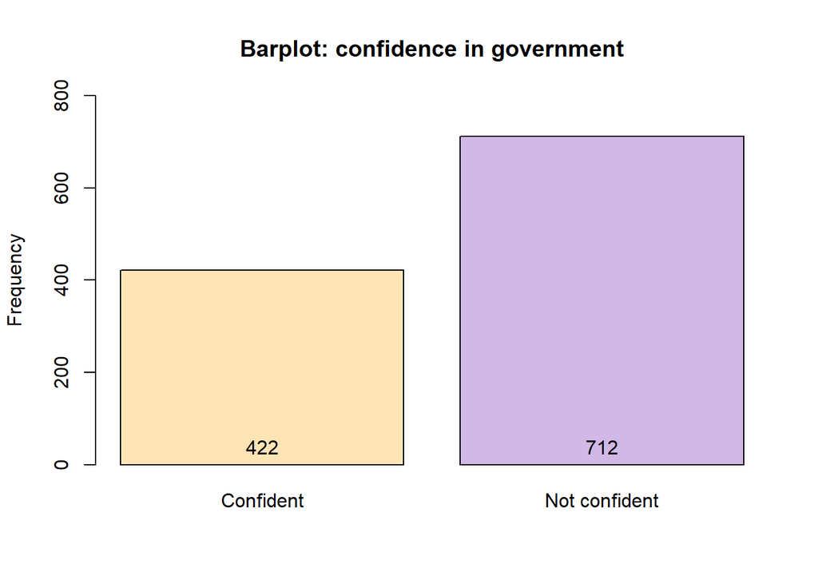

```r
bp_10 <- barplot(table(Mongolia_WVS_EVS$government_conf),
        beside = T,
        ylab = "Frequency",
        ylim = c(0, 800),
        main = "Barplot: confidence in government",
        col = c("#FFE4B5", "#D1B8E6"))
text(bp_10, -1.4, table(Mongolia_WVS_EVS$government_conf), col = "black", pos = 3)
```

**13. Confidence in parliament**: variable type is categorical, values are distributed unevenly: very few observations for category 1 (89 observations). Therefore, we need to recode: I decided to combine into two categories: confident and not confident. Even though the observations are still unevenly distributed, the category “Confident” is now saturated with observations (327 observations).

```r
table(Mongolia_WVS_EVS$E069_07)
```

```
##
##   1   2   3   4
##  89 238 524 283
```

```r
Mongolia_WVS_EVS$parliament_conf <- as.factor(ifelse(Mongolia_WVS_EVS$E069_07 <= 2,
                                                     "Confident",
                                                     "Not confident"))
table(Mongolia_WVS_EVS$parliament_conf)
```

```
##
##     Confident Not confident
##           327           807
```

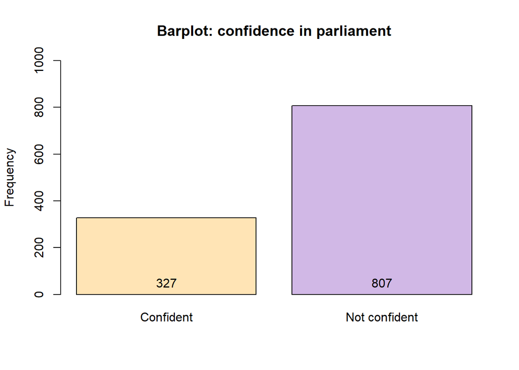

```r
bp_11 <- barplot(table(Mongolia_WVS_EVS$parliament_conf),
        beside = T,
        ylab = "Frequency",
        ylim = c(0, 1000),
        main = "Barplot: confidence in parliament",
        col = c("#FFE4B5", "#D1B8E6"))
text(bp_11, -1.4, table(Mongolia_WVS_EVS$parliament_conf), col = "black", pos = 3)
```

**14. Signing a petition**: variable type is categorical, values are distributed unevenly: very few observations for category 3 (192 observations). Therefore, I decided to increase the saturation of the categories and combine them into two categories: those who have an experience in signing petitions, and those who don’t have.

```r
table(Mongolia_WVS_EVS$E025)
```

```
##
##   1   2   3
## 518 424 192
```

```r
Mongolia_WVS_EVS$petition <- as.factor(ifelse(Mongolia_WVS_EVS$E025 >= 2,
                                              "No experience",
                                              "Have an experience"))
table(Mongolia_WVS_EVS$petition)
```

```
##
## Have an experience      No experience
##                518                616
```

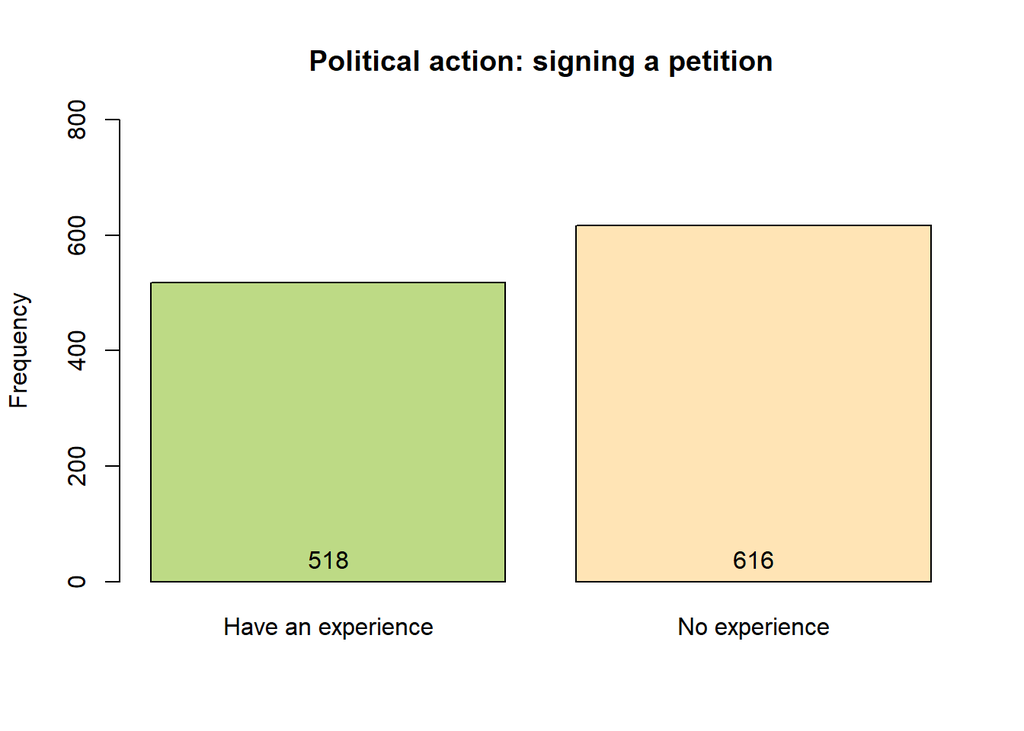

```r
bp_12 <- barplot(table(Mongolia_WVS_EVS$petition),
        beside = T,
        ylab = "Frequency",
        ylim = c(0, 800),
        main = "Political action: signing a petition",
        col = c("#BDDA85", "#FFE4B5"))
text(bp_12, -1.4, table(Mongolia_WVS_EVS$petition), col = "black", pos = 3)
```

**15. Joining boycotts**: variable type is categorical, values are distributed unevenly. Therefore, I decided to increase the saturation of the categories and combine them into two categories: those who have done or might do this actions, and those who would never do it.

```r
table(Mongolia_WVS_EVS$E026)
```

```
##
##   1   2   3
## 213 583 338
```

```r
Mongolia_WVS_EVS$boycott <- as.factor(ifelse(Mongolia_WVS_EVS$E026 <=2,
                                             "Have done or might",
                                             "Would never do"))
table(Mongolia_WVS_EVS$boycott)
```

```
##
## Have done or might     Would never do
##                796                338
```

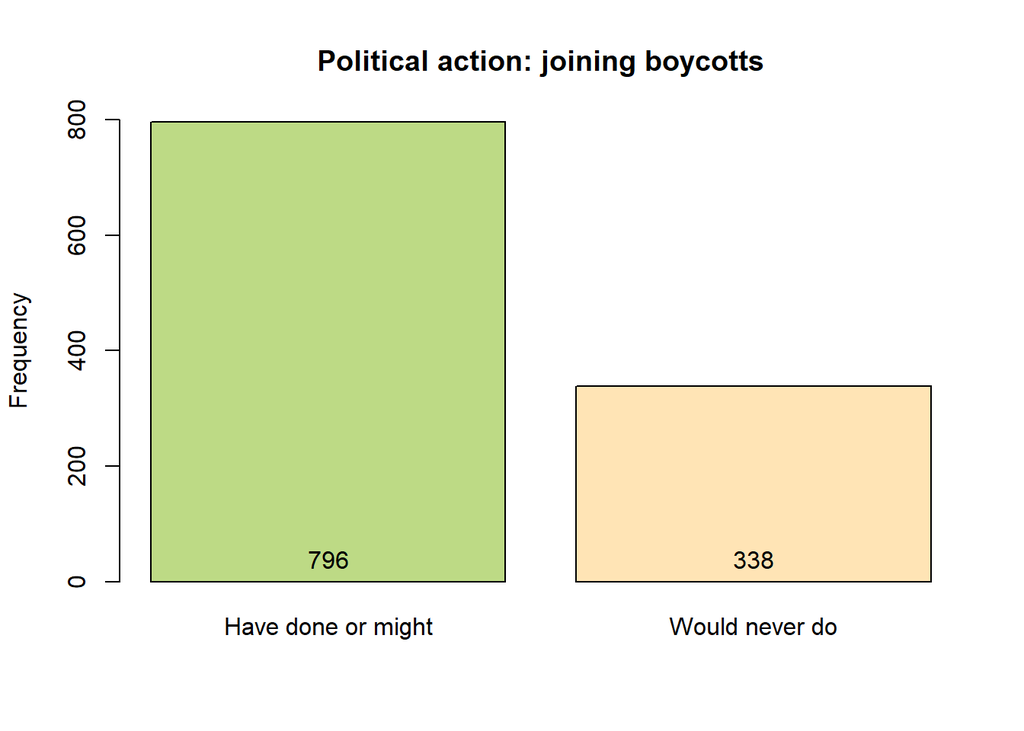

```r
bp_13 <- barplot(table(Mongolia_WVS_EVS$boycott),
        beside = T,
        ylab = "Frequency",
        ylim = c(0, 800),
        main = "Political action: joining boycotts",
        col = c("#BDDA85", "#FFE4B5"))
text(bp_13, -1.4, table(Mongolia_WVS_EVS$boycott), col = "black", pos = 3)
```

**16. Attending lawful/peaceful demonstrations**: variable type is categorical, values are distributed unevenly. Therefore, I decided to increase the saturation of the categories and combine them into two categories: those who have done or might do this actions, and those who would never do it.

```r
table(Mongolia_WVS_EVS$E027)
```

```
##
##   1   2   3
## 228 588 318
```

```r
Mongolia_WVS_EVS$lawful_demonstration <- as.factor(ifelse(Mongolia_WVS_EVS$E027 <= 2,
                                                          "Have done or might",
                                                          "Would never do"))
table(Mongolia_WVS_EVS$lawful_demonstration)
```

```
##
## Have done or might     Would never do
##                816                318
```

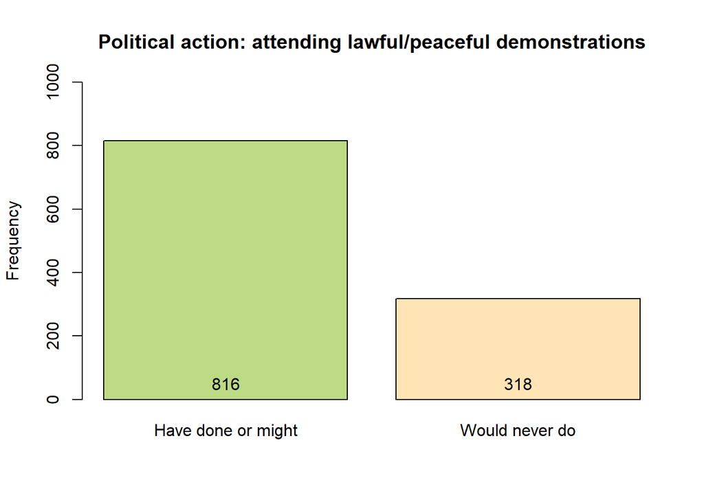

```r
bp_14 <- barplot(table(Mongolia_WVS_EVS$lawful_demonstration),
        beside = T,
        ylab = "Frequency",
        ylim = c(0, 1000),
        main = "Political action: attending lawful/peaceful demonstrations",
        col = c("#BDDA85", "#FFE4B5"))
text(bp_14, -1.4, table(Mongolia_WVS_EVS$lawful_demonstration), col = "black", pos = 3)
```

**17. Joining unofficial strikes**: variable type is categorical, values are distributed unevenly: very few observations for category 1 (165 observations). Therefore, I decided to increase the saturation of the categories and combine them into two categories: those who have done or might do this actions, and those who would never do it.

```r
table(Mongolia_WVS_EVS$E028)
```

```
##
##   1   2   3
## 165 549 420
```

```r
Mongolia_WVS_EVS$strike <- as.factor(ifelse(Mongolia_WVS_EVS$E028 <=2,
                                            "Have done or might",
                                            "Would never do"))
table(Mongolia_WVS_EVS$strike)
```

```
##
## Have done or might     Would never do
##                714                420
```

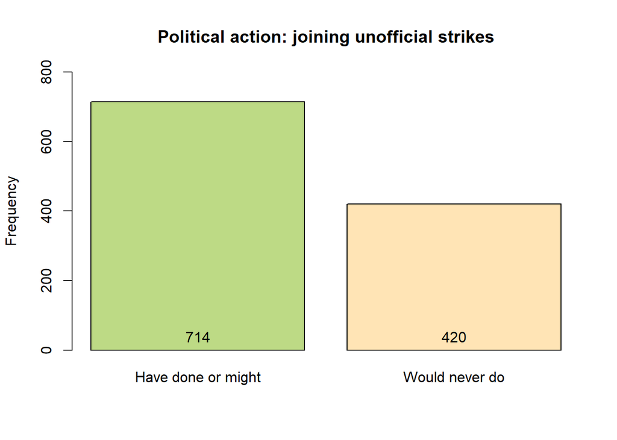

```r
bp_15 <- barplot(table(Mongolia_WVS_EVS$strike),
        beside = T,
        ylab = "Frequency",
        ylim = c(0, 800),
        main = "Political action: joining unofficial strikes",
        col = c("#BDDA85", "#FFE4B5"))
text(bp_15, -1.4, table(Mongolia_WVS_EVS$strike), col = "black", pos = 3)
```

## 2. Descriptive statistics.

**Before running the analysis, let’s discover the nature of the relations in our data – among the outcome and the predictors. Describe simple bivariate tests. What relationships have you discovered? Interpret the results – not only significance, but also the type of the effect.**

**1. Gender**: P-value is not significant (p-value > 0.05), so the null hypothesis can be accepted: there is no association between gender and participation in elections.

```r
chisq.test(Mongolia_WVS_EVS$vote, Mongolia_WVS_EVS$sex)
```

```
##
##  Pearson's Chi-squared test with Yates' continuity correction
##
## data:  Mongolia_WVS_EVS$vote and Mongolia_WVS_EVS$sex
## X-squared = 0.0052537, df = 1, p-value = 0.9422
```

```r
chisq.test(Mongolia_WVS_EVS$vote, Mongolia_WVS_EVS$sex)$stdres
```

```
##                      Mongolia_WVS_EVS$sex
## Mongolia_WVS_EVS$vote    Female      Male
##                     0  0.133367 -0.133367
##                     1 -0.133367  0.133367
```

**2. Age**: p-value is significant (p-value < 0.05), X-squared 22.34 is greater than the critical value 5.991 according to the table for the df = 2, so the null hypothesis can be rejected (that there is no association between variables) and we can speak about the association between age and participation in elections.

Also we can see significant (> |1.96|) and positive st.res. (3.47) for category “55 and more” and regular participation in elections (1): we observe more cases than we can expect.

So, those respondents, who are 55 years and more are more likely to participate in elections always, while those respondents, who are 15-29 years old are less likely to do it: (we can see significant (> |1.96|) and negative st.res. (-4.27) for category “15 - 29” and category “1” - always participate in elections.

```r
chisq.test(Mongolia_WVS_EVS$vote, Mongolia_WVS_EVS$age)
```

```
##
##  Pearson's Chi-squared test
##
## data:  Mongolia_WVS_EVS$vote and Mongolia_WVS_EVS$age
## X-squared = 22.344, df = 2, p-value = 1.406e-05
```

```r
chisq.test(Mongolia_WVS_EVS$vote, Mongolia_WVS_EVS$age)$stdres
```

```
##                      Mongolia_WVS_EVS$age
## Mongolia_WVS_EVS$vote    15 - 29    30 - 49 55 and more
##                     0  4.2782911 -0.8915793  -3.4686205
##                     1 -4.2782911  0.8915793   3.4686205
```

**3. Education**: p-value is significant (p-value < 0.05), X-squared 7.30 is greater than the critical value 3.841 according to the table for the df = 1, so the null hypothesis can be rejected (that there is no association between variables) and we can speak about the association between education and participation in elections.

Also we can see significant (> |1.96|) and positive st.res. (2.76) for category “Tertiary education” and regular participation in elections (1): we observe more cases than we can expect.

So, those respondents, who have got tertiary education are more likely to participate in elections always, while those respondents, who have got secondary education or less are less likely to do it: (we can see significant (> |1.96|) and negative st.res. (-2.76) for category “Secondary education or less” and category “1” - always participate in elections.

```r
chisq.test(Mongolia_WVS_EVS$vote, Mongolia_WVS_EVS$education)
```

```
##
##  Pearson's Chi-squared test with Yates' continuity correction
##
## data:  Mongolia_WVS_EVS$vote and Mongolia_WVS_EVS$education
## X-squared = 7.3016, df = 1, p-value = 0.006889
```

```r
chisq.test(Mongolia_WVS_EVS$vote, Mongolia_WVS_EVS$education)$stdres
```

```
##                      Mongolia_WVS_EVS$education
## Mongolia_WVS_EVS$vote Secondary education or less Tertiary education
##                     0                    2.763563          -2.763563
##                     1                   -2.763563           2.763563
```

**4. Marital status**: p-value is not significant (p-value > 0.05), so the null hypothesis can be accepted: there is no association between marital status and participation in elections.

```r
chisq.test(Mongolia_WVS_EVS$vote, Mongolia_WVS_EVS$marital_st)
```

```
##
##  Pearson's Chi-squared test
##
## data:  Mongolia_WVS_EVS$vote and Mongolia_WVS_EVS$marital_st
## X-squared = 5.68, df = 2, p-value = 0.05843
```

```r
chisq.test(Mongolia_WVS_EVS$vote, Mongolia_WVS_EVS$marital_st)$stdres
```

```
##                      Mongolia_WVS_EVS$marital_st
## Mongolia_WVS_EVS$vote Living together   Married    Single
##                     0       -1.059479 -1.217409  2.374616
##                     1        1.059479  1.217409 -2.374616
```

**5. Religion**: p-value is significant (p-value < 0.05), X-squared 51.25 is greater than the critical value 3.841 according to the table for the df = 1, so the null hypothesis can be rejected (that there is no association between variables) and we can speak about the association between religion status and participation in elections.

Also we can see significant (> |1.96|) and positive st.res. (7.22) for category “Religious person” and regular participation in elections (1): we observe more cases than we can expect.

So, those respondents, who are religious are more likely to participate in elections always, while those respondents, who are not religious are less likely to do it: (we can see significant (> |1.96|) and negative st.res. (-7.22) for category “Not a religious” and category “1” - always participate in elections.

```r
chisq.test(Mongolia_WVS_EVS$vote, Mongolia_WVS_EVS$religion)
```

```
##
##  Pearson's Chi-squared test with Yates' continuity correction
##
## data:  Mongolia_WVS_EVS$vote and Mongolia_WVS_EVS$religion
## X-squared = 51.25, df = 1, p-value = 8.13e-13
```

```r
chisq.test(Mongolia_WVS_EVS$vote, Mongolia_WVS_EVS$religion)$stdres
```

```
##                      Mongolia_WVS_EVS$religion
## Mongolia_WVS_EVS$vote Not a religious person Religious person
##                     0               7.221847        -7.221847
##                     1              -7.221847         7.221847
```

**6. Health status**: P-value is not significant (p-value > 0.05), so the null hypothesis can be accepted: there is no association between health status and participation in elections.

```r
chisq.test(Mongolia_WVS_EVS$vote, Mongolia_WVS_EVS$health)
```

```
##
##  Pearson's Chi-squared test with Yates' continuity correction
##
## data:  Mongolia_WVS_EVS$vote and Mongolia_WVS_EVS$health
## X-squared = 0.5773, df = 1, p-value = 0.4474
```

```r
chisq.test(Mongolia_WVS_EVS$vote, Mongolia_WVS_EVS$health)$stdres
```

```
##                      Mongolia_WVS_EVS$health
## Mongolia_WVS_EVS$vote       Good Not so good
##                     0 -0.8215678   0.8215678
##                     1  0.8215678  -0.8215678
```

For those who always participate in the elections mean level of life satisfaction is 6.70, and for those who not always or never voted mean level of life satisfaction is 6.20. And also differences in level of life satisfaction are significant between two groups because their confidence intervals don’t cross each other.

```r
t.test(Mongolia_WVS_EVS$life_sat ~ Mongolia_WVS_EVS$vote)
```

```
##
##  Welch Two Sample t-test
##
## data:  Mongolia_WVS_EVS$life_sat by Mongolia_WVS_EVS$vote
## t = -4.392, df = 912.9, p-value = 1.255e-05
## alternative hypothesis: true difference in means between group 0 and group 1 is not equal to 0
## 95 percent confidence interval:
##  -0.7278808 -0.2782802
## sample estimates:
## mean in group 0 mean in group 1
##        6.200290        6.703371
```

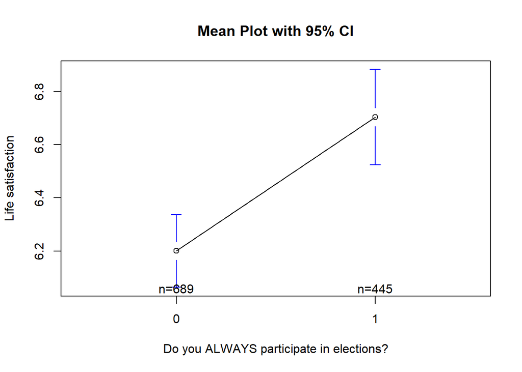

```r
plotmeans(life_sat ~ vote, data = Mongolia_WVS_EVS,
          xlab = "Do you ALWAYS participate in elections?",
          ylab = "Life satisfaction",
          main="Mean Plot with 95% CI")
```

**8. Income**: P-value is significant (p-value < 0.05), so we can speak about the association between these variables. There are differences in income between respondents who always participate in the elections and those who not.

For those who always participate in the elections mean level of income is 5.38, and for those who not always or never voted mean level of income is 5.63. And also confidence intervals almost don’t cross each other.

```r
t.test(Mongolia_WVS_EVS$income ~ Mongolia_WVS_EVS$vote)
```

```
##
##  Welch Two Sample t-test
##
## data:  Mongolia_WVS_EVS$income by Mongolia_WVS_EVS$vote
## t = 2.2317, df = 927.14, p-value = 0.02587
## alternative hypothesis: true difference in means between group 0 and group 1 is not equal to 0
## 95 percent confidence interval:
##  0.03015369 0.46981206
## sample estimates:
## mean in group 0 mean in group 1
##        5.634253        5.384270
```

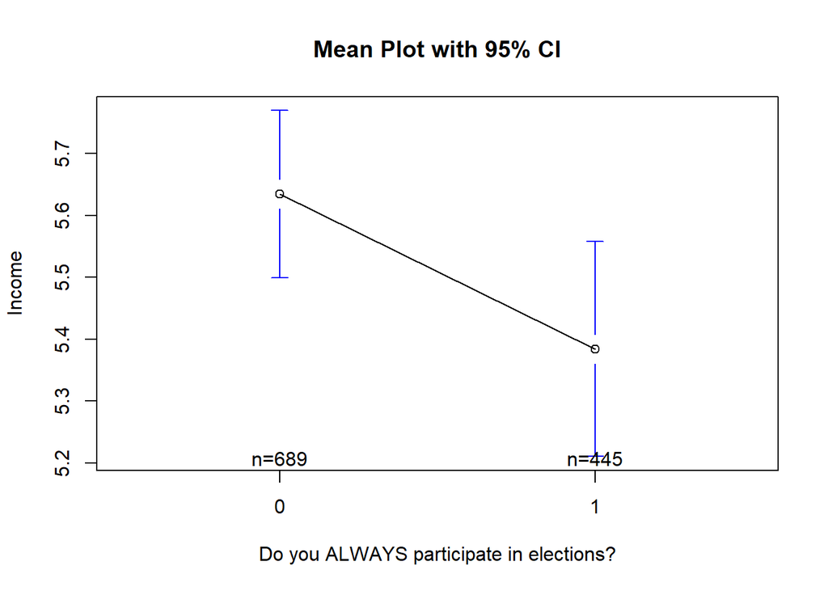

```r
plotmeans(income ~ vote, data = Mongolia_WVS_EVS,
          xlab = "Do you ALWAYS participate in elections?", ylab = "Income",
          main="Mean Plot with 95% CI")
```

**9. Political importance**: P-value is not significant (p-value > 0.05), so the null hypothesis can be accepted: there is no association between the importance of politics and participation in elections.

```r
chisq.test(Mongolia_WVS_EVS$vote, Mongolia_WVS_EVS$pol_importance)
```

```
##
##  Pearson's Chi-squared test with Yates' continuity correction
##
## data:  Mongolia_WVS_EVS$vote and Mongolia_WVS_EVS$pol_importance
## X-squared = 1.7005, df = 1, p-value = 0.1922
```

```r
chisq.test(Mongolia_WVS_EVS$vote, Mongolia_WVS_EVS$pol_importance)$stdres
```

```
##
## Mongolia_WVS_EVS$vote Important Not important
##                     0 -1.364993      1.364993
##                     1  1.364993     -1.364993
```

**10. Political interest**: p-value is significant (p-value < 0.05), X-squared 26.77 is greater than the critical value 3.841 according to the table for the df = 1, so the null hypothesis can be rejected (that there is no association between variables) and we can speak about the association between political interest and participation in elections.

Also we can see significant (> |1.96|) and positive st.res. (5.23) for category “Interested” and regular participation in elections (1): we observe more cases than we can expect.

So, those respondents, who are interested in politics are more likely to participate in elections always, while those respondents, who are not interested in this sphere are less likely to do it: (we can see significant (> |1.96|) and negative st.res. (-5.23) for category “Not interested” and category “1” - always participate in elections.

```r
chisq.test(Mongolia_WVS_EVS$vote, Mongolia_WVS_EVS$pol_interest)
```

```
##
##  Pearson's Chi-squared test with Yates' continuity correction
##
## data:  Mongolia_WVS_EVS$vote and Mongolia_WVS_EVS$pol_interest
## X-squared = 26.767, df = 1, p-value = 2.295e-07
```

```r
chisq.test(Mongolia_WVS_EVS$vote, Mongolia_WVS_EVS$pol_interest)$stdres
```

```
##                      Mongolia_WVS_EVS$pol_interest
## Mongolia_WVS_EVS$vote Interested Not interested
##                     0  -5.238514       5.238514
##                     1   5.238514      -5.238514
```

**11. Government responsibility**: P-value is significant (p-value < 0.05), so we can speak about the association between these variables. There are differences in attitudes toward government responsibility between respondents who always participate in the elections and those who not.

For those who always participate in the elections mean level of government responsibility is 4.37, and for those who not always or never voted mean level government responsibility is 4.88. And also differences in level of government responsibility are significant between two groups because their confidence intervals don’t cross each other.

```r
t.test(Mongolia_WVS_EVS$government_resp ~ Mongolia_WVS_EVS$vote)
```

```
##
##  Welch Two Sample t-test
##
## data:  Mongolia_WVS_EVS$government_resp by Mongolia_WVS_EVS$vote
## t = 3.0816, df = 788.41, p-value = 0.002131
## alternative hypothesis: true difference in means between group 0 and group 1 is not equal to 0
## 95 percent confidence interval:
##  0.1798289 0.8109834
## sample estimates:
## mean in group 0 mean in group 1
##        4.875181        4.379775
```

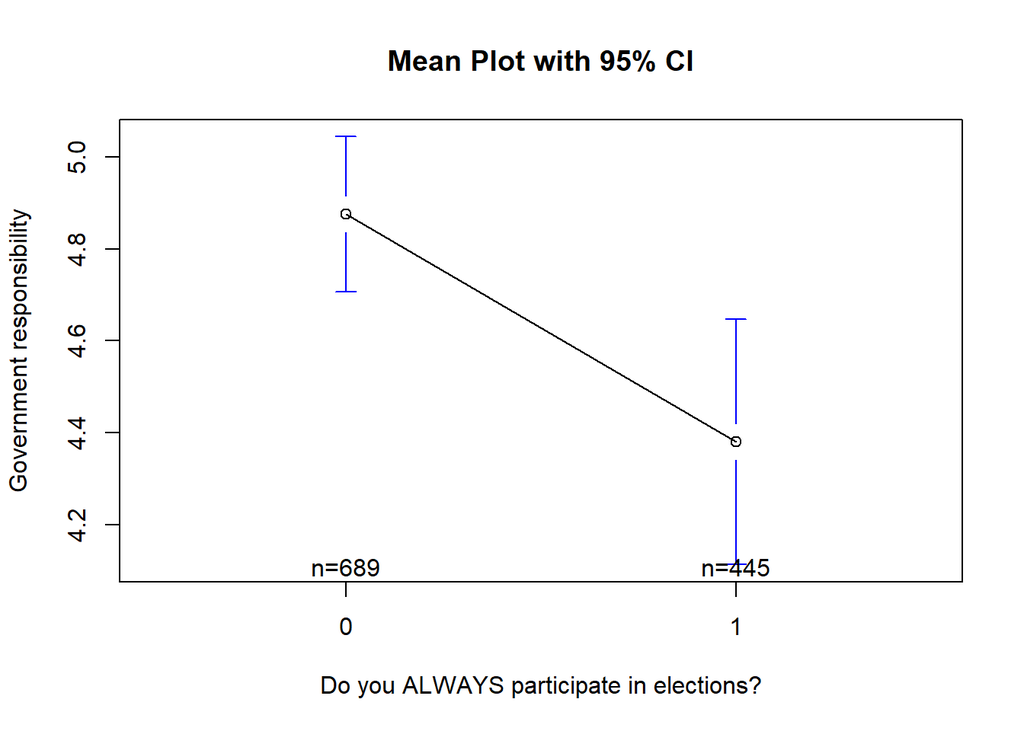

```r
plotmeans(government_resp ~ vote, data = Mongolia_WVS_EVS,
          xlab = "Do you ALWAYS participate in elections?",
          ylab = "Government responsibility",
          main="Mean Plot with 95% CI")
```

**12. Confidence: Government**: p-value is significant (p-value < 0.05), X-squared 5.65 is greater than the critical value 3.841 according to the table for the df = 1, so the null hypothesis can be rejected (that there is no association between variables) and we can speak about the association between confidence in government and participation in elections.

Also we can see significant (> |1.96|) and positive st.res. (2.44) for category “Confident” and regular participation in elections (1): we observe more cases than we can expect.

So, those respondents, who are confident in government are more likely to participate in elections always, while those respondents, who are not confident in government are less likely to do it: (we can see significant (> |1.96|) and negative st.res. (-2.44) for category “Not confident” and category “1” - always participate in elections.

```r
chisq.test(Mongolia_WVS_EVS$vote, Mongolia_WVS_EVS$government_conf)
```

```
##
##  Pearson's Chi-squared test with Yates' continuity correction
##
## data:  Mongolia_WVS_EVS$vote and Mongolia_WVS_EVS$government_conf
## X-squared = 5.6547, df = 1, p-value = 0.01741
```

```r
chisq.test(Mongolia_WVS_EVS$vote, Mongolia_WVS_EVS$government_conf)$stdres
```

```
##
## Mongolia_WVS_EVS$vote Confident Not confident
##                     0 -2.440863      2.440863
##                     1  2.440863     -2.440863
```

**13. Confidence: Parliament**: P-value is not significant (p-value > 0.05), so the null hypothesis can be accepted: there is no association between the confidence in parliament and participation in elections.

```r
chisq.test(Mongolia_WVS_EVS$vote, Mongolia_WVS_EVS$parliament_conf)
```

```
##
##  Pearson's Chi-squared test with Yates' continuity correction
##
## data:  Mongolia_WVS_EVS$vote and Mongolia_WVS_EVS$parliament_conf
## X-squared = 2.5181, df = 1, p-value = 0.1125
```

```r
chisq.test(Mongolia_WVS_EVS$vote, Mongolia_WVS_EVS$parliament_conf)$stdres
```

```
##
## Mongolia_WVS_EVS$vote Confident Not confident
##                     0  1.653993     -1.653993
##                     1 -1.653993      1.653993
```

**14. Political action: signing a petition**: p-value is significant (p-value < 0.05), X-squared 19.56 is greater than the critical value 3.841 according to the table for the df = 1, so the null hypothesis can be rejected (that there is no association between variables) and we can speak about the association between signing petitions and participation in elections.

Also we can see significant (> |1.96|) and positive st.res. (4.48) for category “Have experience” and regular participation in elections (1): we observe more cases than we can expect.

So, those respondents, who have already got experience in signing petitions are more likely to participate in elections always, while those respondents, who have no experience in it are less likely to do it: (we can see significant (> |1.96|) and negative st.res. (-4.48) for category “No experience”.

```r
chisq.test(Mongolia_WVS_EVS$vote, Mongolia_WVS_EVS$petition)
```

```
##
##  Pearson's Chi-squared test with Yates' continuity correction
##
## data:  Mongolia_WVS_EVS$vote and Mongolia_WVS_EVS$petition
## X-squared = 19.564, df = 1, p-value = 9.731e-06
```

```r
chisq.test(Mongolia_WVS_EVS$vote, Mongolia_WVS_EVS$petition)$stdres
```

```
##                      Mongolia_WVS_EVS$petition
## Mongolia_WVS_EVS$vote Have an experience No experience
##                     0          -4.484114      4.484114
##                     1           4.484114     -4.484114
```

**15. Political action: joining boycotts**: p-value is significant (p-value < 0.05), X-squared 10.93 is greater than the critical value 3.841 according to the table for the df = 1, so the null hypothesis can be rejected (that there is no association between variables) and we can speak about the association between joining boycotts and participation in elections.

Also we can see significant (> |1.96|) and positive st.res. (3.37) for category “Would never do” and regular participation in elections (1): we observe more cases than we can expect.

So, those respondents, who would never join boycotts are more likely to participate in elections always, while those respondents, who have already joined or might join boycotts are less likely to do it: (we can see significant (> |1.96|) and negative st.res. (-3.37) for category “Have done or might” and category “1” - always participate in elections.

```r
chisq.test(Mongolia_WVS_EVS$vote, Mongolia_WVS_EVS$boycott)
```

```
##
##  Pearson's Chi-squared test with Yates' continuity correction
##
## data:  Mongolia_WVS_EVS$vote and Mongolia_WVS_EVS$boycott
## X-squared = 10.928, df = 1, p-value = 0.0009471
```

```r
chisq.test(Mongolia_WVS_EVS$vote, Mongolia_WVS_EVS$boycott)$stdres
```

```
##                      Mongolia_WVS_EVS$boycott
## Mongolia_WVS_EVS$vote Have done or might Would never do
##                     0            3.37226       -3.37226
##                     1           -3.37226        3.37226
```

**16. Political action: attending lawful/peaceful demonstrations**: P-value is not significant (p-value > 0.05), so the null hypothesis can be accepted: there is no association between the attending lawful/peaceful demonstrations and participation in elections.

```r
chisq.test(Mongolia_WVS_EVS$vote, Mongolia_WVS_EVS$lawful_demonstration)
```

```
##
##  Pearson's Chi-squared test with Yates' continuity correction
##
## data:  Mongolia_WVS_EVS$vote and Mongolia_WVS_EVS$lawful_demonstration
## X-squared = 0.053699, df = 1, p-value = 0.8167
```

```r
chisq.test(Mongolia_WVS_EVS$vote, Mongolia_WVS_EVS$lawful_demonstration)$stdres
```

```
##
## Mongolia_WVS_EVS$vote Have done or might Would never do
##                     0          0.2994234     -0.2994234
##                     1         -0.2994234      0.2994234
```

**17. Political action: joining unofficial strikes**: P-value is not significant (p-value > 0.05), so the null hypothesis can be accepted: there is no association between joining unofficial strikes and participation in elections.

```r
chisq.test(Mongolia_WVS_EVS$vote, Mongolia_WVS_EVS$strike)
```

```
##
##  Pearson's Chi-squared test with Yates' continuity correction
##
## data:  Mongolia_WVS_EVS$vote and Mongolia_WVS_EVS$strike
## X-squared = 2.9704, df = 1, p-value = 0.0848
```

```r
chisq.test(Mongolia_WVS_EVS$vote, Mongolia_WVS_EVS$strike)$stdres
```

```
##                      Mongolia_WVS_EVS$strike
## Mongolia_WVS_EVS$vote Have done or might Would never do
##                     0           1.786451      -1.786451
##                     1          -1.786451       1.786451
```

## 3. Logistic regression analysis.

**Describe every step you make! Interpret all the results! It’s better to give excessive interpretations than not to interpret enough. Tables without interpretations are not assessed.**

**3.1. Multiple logistic regression. Choose either forwards or backwards method. Choose the best model through model comparison. Interpretation of the final model: odds ratios, predicted probabilities, marginal effects**

I will first add those predictors whose association with voting was significant. And then the rest of the predictors: if they become significant, it will be a sign of multicolleniality.

# Model 1: Age

In this model variable “age” is statistically significant since the p-values are less than 0.05. AIC of this model is 1502.5 (it will be useful to us when comparing with the next model).

**Coefficients** Based on the coefficients in the table, we can say about the direction of the predictor on the chances of regular voting, but we cannot say how much the predictor increases or decreases these chances. Thus, age categories have a positive direction - an increase in the age category leads to an increase in the chances of regular voting compared to category “15 - 29” (0.49 for age 30-49, and 0.78 for age 55+).

**Odds ratios**

1. We observe that the odds of regular voting are increased by a factor of 1.63 for age 30 - 49, it means the chances 30 - 49 years-old respondents regular voting rises by 63% compared to 15-29 years old respondents.
2. Also, we can see that the odds of regular voting are increased by a factor of 2.18 for age 55 and more, it means the chances 55+ years-old respondents regular voting rises by 118% compared to 15-29 years old respondents.

```r
model_1 <-glm(vote ~ age, data = Mongolia_WVS_EVS, family = "binomial")
summary(model_1)
```

```
##
## Call:
## glm(formula = vote ~ age, family = "binomial", data = Mongolia_WVS_EVS)
##
## Deviance Residuals:
##     Min       1Q   Median       3Q      Max
## -1.1420  -1.0217  -0.8385   1.3416   1.5595
##
## Coefficients:
##                Estimate Std. Error z value Pr(>|z|)
## (Intercept)     -0.8645     0.1198  -7.215 5.40e-13 ***
## age30 - 49       0.4865     0.1497   3.249  0.00116 **
## age55 and more   0.7805     0.1684   4.634 3.58e-06 ***
## ---
## Signif. codes:  0 '***' 0.001 '**' 0.01 '*' 0.05 '.' 0.1 ' ' 1
##
## (Dispersion parameter for binomial family taken to be 1)
##
##     Null deviance: 1519.1  on 1133  degrees of freedom
## Residual deviance: 1496.5  on 1131  degrees of freedom
## AIC: 1502.5
##
## Number of Fisher Scoring iterations: 4
```

```r
exp(model_1$coefficients)
```

```
##    (Intercept)     age30 - 49 age55 and more
##      0.4212766      1.6265938      2.1825639
```

# Model 2: + Education

In this model variable “education” is statistically significant since the p-value is less than 0.05. AIC of this model is 1494.8.

**Coefficients** Tertiary education has a positive direction - it increase the chances of regular voting compared to category “secondary or less” (0.40).

**Odds ratios** We observe that the odds of regular voting are increased by a factor of 1.49 for respondents with tertiary education, it means the chances of these respondents regular voting rises by 49% compared to respondents with secondary education or less.

```r
model_2 <-glm(vote ~ age + education, data = Mongolia_WVS_EVS, family = "binomial")
summary(model_2)
```

```
##
## Call:
## glm(formula = vote ~ age + education, family = "binomial", data = Mongolia_WVS_EVS)
##
## Deviance Residuals:
##     Min       1Q   Median       3Q      Max
## -1.2366  -1.0702  -0.8999   1.2833   1.6614
##
## Coefficients:
##                             Estimate Std. Error z value Pr(>|z|)
## (Intercept)                  -1.0903     0.1421  -7.673 1.68e-14 ***
## age30 - 49                    0.4494     0.1507   2.982  0.00287 **
## age55 and more                0.8328     0.1703   4.891 1.00e-06 ***
## educationTertiary education   0.3955     0.1279   3.092  0.00199 **
## ---
## Signif. codes:  0 '***' 0.001 '**' 0.01 '*' 0.05 '.' 0.1 ' ' 1
##
## (Dispersion parameter for binomial family taken to be 1)
##
##     Null deviance: 1519.1  on 1133  degrees of freedom
## Residual deviance: 1486.8  on 1130  degrees of freedom
## AIC: 1494.8
##
## Number of Fisher Scoring iterations: 4
```

```r
exp(model_2$coefficients)
```

```
##                 (Intercept)                  age30 - 49
##                    0.336115                    1.567362
##              age55 and more educationTertiary education
##                    2.299810                    1.485130
```

# Model 3: + Religion

In this model variable “religion” is statistically significant since the p-value is less than 0.05. AIC of this model is 1449.5.

**Coefficients** Being a religious person has a positive direction - it increase the chances of regular voting compared to category “not a religious person” (0.88).

**Odds ratios** We observe that the odds of regular voting are increased by a factor of 2.41 for religious respondents, it means the chances of these respondents regular voting rises by 141% compared to not religious respondents.

```r
model_3 <-glm(vote ~ age + education + religion, data = Mongolia_WVS_EVS,
              family = "binomial")
summary(model_3)
```

```
##
## Call:
## glm(formula = vote ~ age + education + religion, family = "binomial",
##     data = Mongolia_WVS_EVS)
##
## Deviance Residuals:
##     Min       1Q   Median       3Q      Max
## -1.4515  -0.9446  -0.7840   1.2156   1.8064
##
## Coefficients:
##                             Estimate Std. Error z value Pr(>|z|)
## (Intercept)                  -1.4138     0.1546  -9.145  < 2e-16 ***
## age30 - 49                    0.4465     0.1538   2.903  0.00370 **
## age55 and more                0.7689     0.1741   4.415 1.01e-05 ***
## educationTertiary education   0.3916     0.1307   2.997  0.00273 **
## religionReligious person      0.8779     0.1285   6.833 8.31e-12 ***
## ---
## Signif. codes:  0 '***' 0.001 '**' 0.01 '*' 0.05 '.' 0.1 ' ' 1
##
## (Dispersion parameter for binomial family taken to be 1)
##
##     Null deviance: 1519.1  on 1133  degrees of freedom
## Residual deviance: 1439.5  on 1129  degrees of freedom
## AIC: 1449.5
##
## Number of Fisher Scoring iterations: 4
```

```r
exp(model_3$coefficients)
```

```
##                 (Intercept)                  age30 - 49
##                   0.2432246                   1.5628678
##              age55 and more educationTertiary education
##                   2.1573016                   1.4792821
##    religionReligious person
##                   2.4059078
```

# Model 4: + Life satisfaction

In this model variable “life satisfaction” is statistically significant since the p-value is less than 0.05. AIC of this model is 1436.6.

**Coefficients** Life satisfaction has a positive direction - as it increases, the chances of regular voting increase as well (0.13).

**Odds ratios** We observe that the odds of regular voting are multiplied by a factor of 1.14 for every point increase of life satisfaction level. It means the chances of regular voting increase by 14% every time level of life satisfaction becomes higher.

```r
model_4 <-glm(vote ~ age + education + religion + life_sat,
              data = Mongolia_WVS_EVS, family = "binomial")
summary(model_4)
```

```
##
## Call:
## glm(formula = vote ~ age + education + religion + life_sat, family = "binomial",
##     data = Mongolia_WVS_EVS)
##
## Deviance Residuals:
##     Min       1Q   Median       3Q      Max
## -1.6522  -0.9732  -0.7469   1.1627   2.1114
##
## Coefficients:
##                             Estimate Std. Error z value Pr(>|z|)
## (Intercept)                 -2.24735    0.27200  -8.262  < 2e-16 ***
## age30 - 49                   0.45192    0.15470   2.921 0.003486 **
## age55 and more               0.77255    0.17545   4.403 1.07e-05 ***
## educationTertiary education  0.36820    0.13157   2.799 0.005133 **
## religionReligious person     0.85371    0.12944   6.595 4.24e-11 ***
## life_sat                     0.13227    0.03464   3.819 0.000134 ***
## ---
## Signif. codes:  0 '***' 0.001 '**' 0.01 '*' 0.05 '.' 0.1 ' ' 1
##
## (Dispersion parameter for binomial family taken to be 1)
##
##     Null deviance: 1519.1  on 1133  degrees of freedom
## Residual deviance: 1424.6  on 1128  degrees of freedom
## AIC: 1436.6
##
## Number of Fisher Scoring iterations: 4
```

```r
exp(model_4$coefficients)
```

```
##                 (Intercept)                  age30 - 49
##                   0.1056785                   1.5713210
##              age55 and more educationTertiary education
##                   2.1652868                   1.4451268
##    religionReligious person                    life_sat
##                   2.3483430                   1.1414209
```

# Model 5: + Income

In this model variable “income” is statistically significant since the p-value is less than 0.05. AIC of this model is 1431.

**Coefficients** Income has a negative direction - as it increases, the chances of regular voting decrease (-0.10).

**Odds ratios** We observe that the odds of regular voting are multiplied by a factor of 0.91 for every point increase of income level. It means the chances of regular voting decrease by 9% every time level of income becomes higher.

```r
model_5 <-glm(vote ~ age + education + religion + life_sat + income,
              data = Mongolia_WVS_EVS, family = "binomial")
summary(model_5)
```

```
##
## Call:
## glm(formula = vote ~ age + education + religion + life_sat +
##     income, family = "binomial", data = Mongolia_WVS_EVS)
##
## Deviance Residuals:
##     Min       1Q   Median       3Q      Max
## -1.7016  -0.9636  -0.7228   1.1625   2.0213
##
## Coefficients:
##                             Estimate Std. Error z value Pr(>|z|)
## (Intercept)                 -1.79295    0.31484  -5.695 1.24e-08 ***
## age30 - 49                   0.42983    0.15540   2.766  0.00568 **
## age55 and more               0.75072    0.17607   4.264 2.01e-05 ***
## educationTertiary education  0.41573    0.13332   3.118  0.00182 **
## religionReligious person     0.84679    0.12991   6.518 7.12e-11 ***
## life_sat                     0.14453    0.03503   4.125 3.70e-05 ***
## income                      -0.09843    0.03580  -2.750  0.00597 **
## ---
## Signif. codes:  0 '***' 0.001 '**' 0.01 '*' 0.05 '.' 0.1 ' ' 1
##
## (Dispersion parameter for binomial family taken to be 1)
##
##     Null deviance: 1519.1  on 1133  degrees of freedom
## Residual deviance: 1417.0  on 1127  degrees of freedom
## AIC: 1431
##
## Number of Fisher Scoring iterations: 4
```

```r
exp(model_5$coefficients)
```

```
##                 (Intercept)                  age30 - 49
##                   0.1664678                   1.5369929
##              age55 and more educationTertiary education
##                   2.1185142                   1.5154747
##    religionReligious person                    life_sat
##                   2.3321398                   1.1554907
##                      income
##                   0.9062602
```

# Model 6: + Political interest

In this model variable “political interest” is statistically significant since the p-value is less than 0.05. AIC of this model is 1420.3.

**Coefficients** Having an interest in politic has a positive direction - it increase the chances of regular voting compared to category “not interested” (0.49).

**Odds ratios** We observe that the odds of regular voting are increased by a factor of 1.63 for respondents who are interested in politics, it means the chances of these respondents regular voting rises by 63% compared to respondents without the interest in this sphere.

```r
Mongolia_WVS_EVS <- within(Mongolia_WVS_EVS,
                           pol_interest <- relevel(pol_interest,
                                                   ref = "Not interested"))

model_6 <-glm(vote ~ age + education + religion + life_sat + income +
                pol_interest, data = Mongolia_WVS_EVS, family = "binomial")
summary(model_6)
```

```
##
## Call:
## glm(formula = vote ~ age + education + religion + life_sat +
##     income + pol_interest, family = "binomial", data = Mongolia_WVS_EVS)
##
## Deviance Residuals:
##     Min       1Q   Median       3Q      Max
## -1.8119  -0.9523  -0.7034   1.1536   2.0491
##
## Coefficients:
##                             Estimate Std. Error z value Pr(>|z|)
## (Intercept)                 -1.87367    0.31748  -5.902 3.60e-09 ***
## age30 - 49                   0.42254    0.15622   2.705 0.006834 **
## age55 and more               0.71570    0.17742   4.034 5.48e-05 ***
## educationTertiary education  0.39795    0.13409   2.968 0.003000 **
## religionReligious person     0.77215    0.13206   5.847 5.00e-09 ***
## life_sat                     0.14106    0.03512   4.016 5.92e-05 ***
## income                      -0.10004    0.03596  -2.782 0.005410 **
## pol_interestInterested       0.48572    0.13620   3.566 0.000362 ***
## ---
## Signif. codes:  0 '***' 0.001 '**' 0.01 '*' 0.05 '.' 0.1 ' ' 1
##
## (Dispersion parameter for binomial family taken to be 1)
##
##     Null deviance: 1519.1  on 1133  degrees of freedom
## Residual deviance: 1404.3  on 1126  degrees of freedom
## AIC: 1420.3
##
## Number of Fisher Scoring iterations: 4
```

```r
exp(model_6$coefficients)
```

```
##                 (Intercept)                  age30 - 49
##                   0.1535584                   1.5258281
##              age55 and more educationTertiary education
##                   2.0456170                   1.4887752
##    religionReligious person                    life_sat
##                   2.1644155                   1.1514972
##                      income      pol_interestInterested
##                   0.9048049                   1.6253459
```

# Model 7: + Government responsibility

In this model variable “government responsibility” is statistically significant since the p-value is less than 0.05. AIC of this model is 1414.7.

**Coefficients** Attitudes towards government responsibility have a negative direction - as it increases, the chances of regular voting decrease (-0.07).

**Odds ratios** We observe that the odds of regular voting are multiplied by a factor of 0.93 for every point increase of government responsibility. It means the chances of regular voting decrease by 7% every time level of government responsibility becomes higher.

```r
model_7 <-glm(vote ~ age + education + religion + life_sat + income +
              pol_interest + government_resp, data = Mongolia_WVS_EVS,
              family = "binomial")
summary(model_7)
```

```
##
## Call:
## glm(formula = vote ~ age + education + religion + life_sat +
##     income + pol_interest + government_resp, family = "binomial",
##     data = Mongolia_WVS_EVS)
##
## Deviance Residuals:
##     Min       1Q   Median       3Q      Max
## -1.7357  -0.9578  -0.6948   1.1522   2.1104
##
## Coefficients:
##                             Estimate Std. Error z value Pr(>|z|)
## (Intercept)                 -1.38414    0.36387  -3.804 0.000142 ***
## age30 - 49                   0.42300    0.15665   2.700 0.006929 **
## age55 and more               0.71765    0.17788   4.034 5.47e-05 ***
## educationTertiary education  0.38347    0.13462   2.849 0.004391 **
## religionReligious person     0.79251    0.13287   5.965 2.45e-09 ***
## life_sat                     0.12248    0.03595   3.407 0.000657 ***
## income                      -0.10647    0.03626  -2.936 0.003323 **
## pol_interestInterested       0.48446    0.13665   3.545 0.000392 ***
## government_resp             -0.07218    0.02638  -2.736 0.006218 **
## ---
## Signif. codes:  0 '***' 0.001 '**' 0.01 '*' 0.05 '.' 0.1 ' ' 1
##
## (Dispersion parameter for binomial family taken to be 1)
##
##     Null deviance: 1519.1  on 1133  degrees of freedom
## Residual deviance: 1396.7  on 1125  degrees of freedom
## AIC: 1414.7
##
## Number of Fisher Scoring iterations: 4
```

```r
exp(model_7$coefficients)
```

```
##                 (Intercept)                  age30 - 49
##                   0.2505398                   1.5265343
##              age55 and more educationTertiary education
##                   2.0496188                   1.4673674
##    religionReligious person                    life_sat
##                   2.2089267                   1.1303012
##                      income      pol_interestInterested
##                   0.8989998                   1.6233003
##             government_resp
##                   0.9303613
```

# Model 8: + Confidence in government

**Coefficients** Being confident in politics has a positive direction - it increase the chances of regular voting compared to category “not confident” (0.33).

**Odds ratios** We observe that the odds of regular voting are increased by a factor of 1.39 for respondents who are confident in government, it means the chances of these respondents regular voting rises by 39% compared to respondents without the confidence in government.

```r
Mongolia_WVS_EVS <- within(Mongolia_WVS_EVS,
                           government_conf <- relevel(government_conf,
                                                      ref = "Not confident"))

model_8 <-glm(vote ~ age + education + religion + life_sat + income +
                pol_interest + government_resp + government_conf,
              data = Mongolia_WVS_EVS, family = "binomial")
summary(model_8)
```

```
##
## Call:
## glm(formula = vote ~ age + education + religion + life_sat +
##     income + pol_interest + government_resp + government_conf,
##     family = "binomial", data = Mongolia_WVS_EVS)
##
## Deviance Residuals:
##     Min       1Q   Median       3Q      Max
## -1.8253  -0.9401  -0.6978   1.1356   2.0342
##
## Coefficients:
##                             Estimate Std. Error z value Pr(>|z|)
## (Intercept)                 -1.47135    0.36725  -4.006 6.17e-05 ***
## age30 - 49                   0.43005    0.15720   2.736 0.006225 **
## age55 and more               0.70983    0.17845   3.978 6.95e-05 ***
## educationTertiary education  0.38201    0.13500   2.830 0.004660 **
## religionReligious person     0.80676    0.13348   6.044 1.50e-09 ***
## life_sat                     0.12367    0.03607   3.428 0.000607 ***
## income                      -0.11210    0.03652  -3.069 0.002146 **
## pol_interestInterested       0.45549    0.13744   3.314 0.000920 ***
## government_resp             -0.07436    0.02647  -2.810 0.004961 **
## government_confConfident     0.32890    0.13360   2.462 0.013824 *
## ---
## Signif. codes:  0 '***' 0.001 '**' 0.01 '*' 0.05 '.' 0.1 ' ' 1
##
## (Dispersion parameter for binomial family taken to be 1)
##
##     Null deviance: 1519.1  on 1133  degrees of freedom
## Residual deviance: 1390.7  on 1124  degrees of freedom
## AIC: 1410.7
##
## Number of Fisher Scoring iterations: 4
```

```r
exp(model_8$coefficients)
```

```
##                 (Intercept)                  age30 - 49
##                   0.2296153                   1.5373396
##              age55 and more educationTertiary education
##                   2.0336437                   1.4652246
##    religionReligious person                    life_sat
##                   2.2406366                   1.1316400
##                      income      pol_interestInterested
##                   0.8939551                   1.5769469
##             government_resp    government_confConfident
##                   0.9283408                   1.3894373
```

# Model 9: + Signing a petition

In this model variable “signing a petition” is statistically significant since the p-value is less than 0.05. AIC of this model is 1393.7.

**Coefficients** Having experience in signing a petition has a positive direction - it increase the chances of regular voting compared to category “no experience” (0.58).

**Odds ratios** We observe that the odds of regular voting are increased by a factor of 1.78 for respondents who have already signed a petition, it means the chances of these respondents regular voting rises by 78% compared to respondents without experience in signing a petition.

```r
Mongolia_WVS_EVS <- within(Mongolia_WVS_EVS,
                           petition <- relevel(petition,
                                               ref = "No experience"))

model_9 <-glm(vote ~ age + education + religion + life_sat + income +
                pol_interest + government_resp + government_conf + petition,
              data = Mongolia_WVS_EVS, family = "binomial")
summary(model_9)
```

```
##
## Call:
## glm(formula = vote ~ age + education + religion + life_sat +
##     income + pol_interest + government_resp + government_conf +
##     petition, family = "binomial", data = Mongolia_WVS_EVS)
##
## Deviance Residuals:
##     Min       1Q   Median       3Q      Max
## -1.7949  -0.9455  -0.6659   1.1005   2.1560
##
## Coefficients:
##                             Estimate Std. Error z value Pr(>|z|)
## (Intercept)                 -1.65154    0.37350  -4.422 9.79e-06 ***
## age30 - 49                   0.41870    0.15850   2.642 0.008252 **
## age55 and more               0.72324    0.18028   4.012 6.02e-05 ***
## educationTertiary education  0.34724    0.13637   2.546 0.010890 *
## religionReligious person     0.83935    0.13509   6.213 5.19e-10 ***
## life_sat                     0.12041    0.03642   3.306 0.000945 ***
## income                      -0.12961    0.03706  -3.497 0.000470 ***
## pol_interestInterested       0.43694    0.13882   3.148 0.001646 **
## government_resp             -0.06556    0.02673  -2.453 0.014164 *
## government_confConfident     0.33331    0.13478   2.473 0.013399 *
## petitionHave an experience   0.57567    0.13265   4.340 1.43e-05 ***
## ---
## Signif. codes:  0 '***' 0.001 '**' 0.01 '*' 0.05 '.' 0.1 ' ' 1
##
## (Dispersion parameter for binomial family taken to be 1)
##
##     Null deviance: 1519.1  on 1133  degrees of freedom
## Residual deviance: 1371.7  on 1123  degrees of freedom
## AIC: 1393.7
##
## Number of Fisher Scoring iterations: 4
```

```r
exp(model_9$coefficients)
```

```
##                 (Intercept)                  age30 - 49
##                   0.1917545                   1.5199882
##              age55 and more educationTertiary education
##                   2.0610939                   1.4151554
##    religionReligious person                    life_sat
##                   2.3148644                   1.1279574
##                      income      pol_interestInterested
##                   0.8784410                   1.5479667
##             government_resp    government_confConfident
##                   0.9365404                   1.3955822
##  petitionHave an experience
##                   1.7783193
```

# Model 10: + Joining boycotts

In this model variable “joining boycotts” is statistically significant since the p-value is less than 0.05. AIC of this model is 1376.8.

**Coefficients** Joining boycotts has a negative direction - it decrease the chances of regular voting compared to category “would never do” (-0.65).

**Odds ratios** We observe that the odds of regular voting are decreased by a factor of 0.52 for respondents who have already joined boycotts or might join, it means the chances of these respondents regular voting decries by 48% compared to respondents who would never do it.

```r
Mongolia_WVS_EVS <- within(Mongolia_WVS_EVS,
                           boycott <- relevel(boycott, ref = "Would never do"))


model_10 <-glm(vote ~ age + education + religion + life_sat + income +
                pol_interest + government_resp + government_conf + petition +
                 boycott,
              data = Mongolia_WVS_EVS, family = "binomial")
summary(model_10)
```

```
##
## Call:
## glm(formula = vote ~ age + education + religion + life_sat +
##     income + pol_interest + government_resp + government_conf +
##     petition + boycott, family = "binomial", data = Mongolia_WVS_EVS)
##
## Deviance Residuals:
##     Min       1Q   Median       3Q      Max
## -1.9566  -0.9421  -0.6470   1.0891   2.2669
##
## Coefficients:
##                             Estimate Std. Error z value Pr(>|z|)
## (Intercept)                 -1.32669    0.38166  -3.476 0.000509 ***
## age30 - 49                   0.44776    0.15953   2.807 0.005005 **
## age55 and more               0.74597    0.18204   4.098 4.17e-05 ***
## educationTertiary education  0.41472    0.13883   2.987 0.002815 **
## religionReligious person     0.79192    0.13676   5.790 7.02e-09 ***
## life_sat                     0.11429    0.03669   3.115 0.001840 **
## income                      -0.12048    0.03730  -3.230 0.001239 **
## pol_interestInterested       0.47110    0.14050   3.353 0.000800 ***
## government_resp             -0.06841    0.02694  -2.540 0.011093 *
## government_confConfident     0.36832    0.13624   2.703 0.006862 **
## petitionHave an experience   0.71946    0.13879   5.184 2.18e-07 ***
## boycottHave done or might   -0.65328    0.15104  -4.325 1.52e-05 ***
## ---
## Signif. codes:  0 '***' 0.001 '**' 0.01 '*' 0.05 '.' 0.1 ' ' 1
##
## (Dispersion parameter for binomial family taken to be 1)
##
##     Null deviance: 1519.1  on 1133  degrees of freedom
## Residual deviance: 1352.8  on 1122  degrees of freedom
## AIC: 1376.8
##
## Number of Fisher Scoring iterations: 4
```

```r
exp(model_10$coefficients)
```

```
##                 (Intercept)                  age30 - 49
##                   0.2653542                   1.5648036
##              age55 and more educationTertiary education
##                   2.1084807                   1.5139522
##    religionReligious person                    life_sat
##                   2.2076261                   1.1210717
##                      income      pol_interestInterested
##                   0.8864946                   1.6017496
##             government_resp    government_confConfident
##                   0.9338755                   1.4453014
##  petitionHave an experience   boycottHave done or might
##                   2.0533177                   0.5203348
```

# Model 11: + Joining unofficial strikes

In this model variable “joining unofficial strikes” is not statistically significant since the p-value is more than 0.05. AIC of this model is 1378.8 (it became higher).

```r
model_11 <-glm(vote ~ age + education + religion + life_sat + income +
                pol_interest + government_resp + government_conf + petition +
                 boycott + strike,
              data = Mongolia_WVS_EVS, family = "binomial")
summary(model_11)
```

```
##
## Call:
## glm(formula = vote ~ age + education + religion + life_sat +
##     income + pol_interest + government_resp + government_conf +
##     petition + boycott + strike, family = "binomial", data = Mongolia_WVS_EVS)
##
## Deviance Residuals:
##     Min       1Q   Median       3Q      Max
## -1.9540  -0.9429  -0.6472   1.0895   2.2676
##
## Coefficients:
##                              Estimate Std. Error z value Pr(>|z|)
## (Intercept)                 -1.332696   0.398541  -3.344 0.000826 ***
## age30 - 49                   0.447576   0.159573   2.805 0.005034 **
## age55 and more               0.745296   0.182496   4.084 4.43e-05 ***
## educationTertiary education  0.414794   0.138836   2.988 0.002811 **
## religionReligious person     0.792025   0.136784   5.790 7.02e-09 ***
## life_sat                     0.114313   0.036692   3.115 0.001837 **
## income                      -0.120479   0.037302  -3.230 0.001239 **
## pol_interestInterested       0.470424   0.141092   3.334 0.000856 ***
## government_resp             -0.068356   0.026957  -2.536 0.011220 *
## government_confConfident     0.367966   0.136404   2.698 0.006984 **
## petitionHave an experience   0.720153   0.139433   5.165 2.41e-07 ***
## boycottHave done or might   -0.649341   0.168752  -3.848 0.000119 ***
## strikeWould never do         0.008188   0.156386   0.052 0.958243
## ---
## Signif. codes:  0 '***' 0.001 '**' 0.01 '*' 0.05 '.' 0.1 ' ' 1
##
## (Dispersion parameter for binomial family taken to be 1)
##
##     Null deviance: 1519.1  on 1133  degrees of freedom
## Residual deviance: 1352.8  on 1121  degrees of freedom
## AIC: 1378.8
##
## Number of Fisher Scoring iterations: 4
```

```r
exp(model_11$coefficients)
```

```
##                 (Intercept)                  age30 - 49
##                   0.2637651                   1.5645151
##              age55 and more educationTertiary education
##                   2.1070657                   1.5140582
##    religionReligious person                    life_sat
##                   2.2078628                   1.1211030
##                      income      pol_interestInterested
##                   0.8864957                   1.6006726
##             government_resp    government_confConfident
##                   0.9339276                   1.4447926
##  petitionHave an experience   boycottHave done or might
##                   2.0547485                   0.5223900
##        strikeWould never do
##                   1.0082218
```

# Model 12: + Sex

In this model variable “sex” is not statistically significant since the p-value is more than 0.05. AIC of this model is 1380.4 (it again became higher).

```r
model_12 <-glm(vote ~ age + education + religion + life_sat + income +
                pol_interest + government_resp + government_conf + petition +
                 boycott + strike + sex,
              data = Mongolia_WVS_EVS, family = "binomial")
summary(model_12)
```

```
##
## Call:
## glm(formula = vote ~ age + education + religion + life_sat +
##     income + pol_interest + government_resp + government_conf +
##     petition + boycott + strike + sex, family = "binomial", data = Mongolia_WVS_EVS)
##
## Deviance Residuals:
##     Min       1Q   Median       3Q      Max
## -1.9731  -0.9427  -0.6469   1.0927   2.2841
##
## Coefficients:
##                              Estimate Std. Error z value Pr(>|z|)
## (Intercept)                 -1.363980   0.402256  -3.391 0.000697 ***
## age30 - 49                   0.447326   0.159598   2.803 0.005066 **
## age55 and more               0.746604   0.182519   4.091 4.30e-05 ***
## educationTertiary education  0.418808   0.139066   3.012 0.002599 **
## religionReligious person     0.796939   0.137075   5.814 6.10e-09 ***
## life_sat                     0.114741   0.036719   3.125 0.001779 **
## income                      -0.122005   0.037401  -3.262 0.001106 **
## pol_interestInterested       0.464728   0.141433   3.286 0.001017 **
## government_resp             -0.068610   0.026967  -2.544 0.010951 *
## government_confConfident     0.365711   0.136516   2.679 0.007387 **
## petitionHave an experience   0.720200   0.139457   5.164 2.41e-07 ***
## boycottHave done or might   -0.651483   0.168851  -3.858 0.000114 ***
## strikeWould never do         0.009879   0.156478   0.063 0.949659
## sexMale                      0.078197   0.132540   0.590 0.555200
## ---
## Signif. codes:  0 '***' 0.001 '**' 0.01 '*' 0.05 '.' 0.1 ' ' 1
##
## (Dispersion parameter for binomial family taken to be 1)
##
##     Null deviance: 1519.1  on 1133  degrees of freedom
## Residual deviance: 1352.4  on 1120  degrees of freedom
## AIC: 1380.4
##
## Number of Fisher Scoring iterations: 4
```

```r
exp(model_12$coefficients)
```

```
##                 (Intercept)                  age30 - 49
##                   0.2556413                   1.5641235
##              age55 and more educationTertiary education
##                   2.1098221                   1.5201484
##    religionReligious person                    life_sat
##                   2.2187390                   1.1215828
##                      income      pol_interestInterested
##                   0.8851441                   1.5915807
##             government_resp    government_confConfident
##                   0.9336906                   1.4415387
##  petitionHave an experience   boycottHave done or might
##                   2.0548438                   0.5212721
##        strikeWould never do                     sexMale
##                   1.0099281                   1.0813355
```

# Model 13: + Marital status

In this model variable “marital status” is not statistically significant since the p-value is more than 0.05. AIC of this model is 1384 (it became higher).

```r
model_13 <-glm(vote ~ age + education + religion + life_sat + income +
                pol_interest + government_resp + government_conf + petition +
                 boycott + strike + sex + marital_st,
              data = Mongolia_WVS_EVS, family = "binomial")
summary(model_13)
```

```
##
## Call:
## glm(formula = vote ~ age + education + religion + life_sat +
##     income + pol_interest + government_resp + government_conf +
##     petition + boycott + strike + sex + marital_st, family = "binomial",
##     data = Mongolia_WVS_EVS)
##
## Deviance Residuals:
##     Min       1Q   Median       3Q      Max
## -1.9616  -0.9448  -0.6452   1.0926   2.2913
##
## Coefficients:
##                              Estimate Std. Error z value Pr(>|z|)
## (Intercept)                 -1.257395   0.437522  -2.874 0.004054 **
## age30 - 49                   0.425463   0.173594   2.451 0.014250 *
## age55 and more               0.730159   0.189420   3.855 0.000116 ***
## educationTertiary education  0.415206   0.139936   2.967 0.003006 **
## religionReligious person     0.795874   0.137546   5.786 7.20e-09 ***
## life_sat                     0.116074   0.036884   3.147 0.001650 **
## income                      -0.124533   0.037638  -3.309 0.000937 ***
## pol_interestInterested       0.467295   0.141510   3.302 0.000959 ***
## government_resp             -0.068487   0.026995  -2.537 0.011180 *
## government_confConfident     0.360046   0.136907   2.630 0.008542 **
## petitionHave an experience   0.712331   0.139949   5.090 3.58e-07 ***
## boycottHave done or might   -0.656632   0.169355  -3.877 0.000106 ***
## strikeWould never do         0.009047   0.156471   0.058 0.953891
## sexMale                      0.077938   0.132631   0.588 0.556781
## marital_stMarried           -0.095076   0.163264  -0.582 0.560334
## marital_stSingle            -0.114194   0.194943  -0.586 0.558022
## ---
## Signif. codes:  0 '***' 0.001 '**' 0.01 '*' 0.05 '.' 0.1 ' ' 1
##
## (Dispersion parameter for binomial family taken to be 1)
##
##     Null deviance: 1519.1  on 1133  degrees of freedom
## Residual deviance: 1352.0  on 1118  degrees of freedom
## AIC: 1384
##
## Number of Fisher Scoring iterations: 4
```

```r
exp(model_13$coefficients)
```

```
##                 (Intercept)                  age30 - 49
##                   0.2843940                   1.5302987
##              age55 and more educationTertiary education
##                   2.0754115                   1.5146824
##    religionReligious person                    life_sat
##                   2.2163783                   1.1230785
##                      income      pol_interestInterested
##                   0.8829088                   1.5956713
##             government_resp    government_confConfident
##                   0.9338057                   1.4333960
##  petitionHave an experience   boycottHave done or might
##                   2.0387372                   0.5185951
##        strikeWould never do                     sexMale
##                   1.0090885                   1.0810554
##           marital_stMarried            marital_stSingle
##                   0.9093038                   0.8920847
```

# Model 14: + Health status

In this model variable “health status” is not statistically significant since the p-value is more than 0.05. AIC of this model is 1386 (it became higher).

```r
model_14 <-glm(vote ~ age + education + religion + life_sat + income +
                pol_interest + government_resp + government_conf + petition +
                 boycott + strike + sex + marital_st + health,
              data = Mongolia_WVS_EVS, family = "binomial")
summary(model_14)
```

```
##
## Call:
## glm(formula = vote ~ age + education + religion + life_sat +
##     income + pol_interest + government_resp + government_conf +
##     petition + boycott + strike + sex + marital_st + health,
##     family = "binomial", data = Mongolia_WVS_EVS)
##
## Deviance Residuals:
##     Min       1Q   Median       3Q      Max
## -1.9578  -0.9458  -0.6460   1.0915   2.2888
##
## Coefficients:
##                              Estimate Std. Error z value Pr(>|z|)
## (Intercept)                 -1.248391   0.446007  -2.799 0.005125 **
## age30 - 49                   0.425503   0.173596   2.451 0.014241 *
## age55 and more               0.730820   0.189528   3.856 0.000115 ***
## educationTertiary education  0.415020   0.139943   2.966 0.003020 **
## religionReligious person     0.794586   0.138092   5.754 8.71e-09 ***
## life_sat                     0.115953   0.036899   3.142 0.001676 **
## income                      -0.124952   0.037856  -3.301 0.000964 ***
## pol_interestInterested       0.465900   0.142139   3.278 0.001046 **
## government_resp             -0.068561   0.027005  -2.539 0.011121 *
## government_confConfident     0.360484   0.136971   2.632 0.008493 **
## petitionHave an experience   0.712943   0.140074   5.090 3.59e-07 ***
## boycottHave done or might   -0.655771   0.169563  -3.867 0.000110 ***
## strikeWould never do         0.008884   0.156489   0.057 0.954727
## sexMale                      0.077757   0.132644   0.586 0.557737
## marital_stMarried           -0.094402   0.163389  -0.578 0.563417
## marital_stSingle            -0.114515   0.194967  -0.587 0.556966
## healthNot so good           -0.014192   0.136606  -0.104 0.917258
## ---
## Signif. codes:  0 '***' 0.001 '**' 0.01 '*' 0.05 '.' 0.1 ' ' 1
##
## (Dispersion parameter for binomial family taken to be 1)
##
##     Null deviance: 1519.1  on 1133  degrees of freedom
## Residual deviance: 1352.0  on 1117  degrees of freedom
## AIC: 1386
##
## Number of Fisher Scoring iterations: 4
```

```r
exp(model_14$coefficients)
```

```
##                 (Intercept)                  age30 - 49
##                   0.2869661                   1.5303601
##              age55 and more educationTertiary education
##                   2.0767819                   1.5144014
##    religionReligious person                    life_sat
##                   2.2135239                   1.1229430
##                      income      pol_interestInterested
##                   0.8825394                   1.5934470
##             government_resp    government_confConfident
##                   0.9337361                   1.4340227
##  petitionHave an experience   boycottHave done or might
##                   2.0399867                   0.5190419
##        strikeWould never do                     sexMale
##                   1.0089238                   1.0808597
##           marital_stMarried            marital_stSingle
##                   0.9099172                   0.8917987
##           healthNot so good
##                   0.9859085
```

# Model 15: + Political importance

```r
model_15 <-glm(vote ~ age + education + religion + life_sat + income +
                pol_interest + government_resp + government_conf + petition +
                 boycott + strike + sex + marital_st + health + pol_importance,
              data = Mongolia_WVS_EVS, family = "binomial")
summary(model_15)
```

```
##
## Call:
## glm(formula = vote ~ age + education + religion + life_sat +
##     income + pol_interest + government_resp + government_conf +
##     petition + boycott + strike + sex + marital_st + health +
##     pol_importance, family = "binomial", data = Mongolia_WVS_EVS)
##
## Deviance Residuals:
##     Min       1Q   Median       3Q      Max
## -1.9173  -0.9465  -0.6327   1.0861   2.2550
##
## Coefficients:
##                              Estimate Std. Error z value Pr(>|z|)
## (Intercept)                 -1.133501   0.453614  -2.499 0.012461 *
## age30 - 49                   0.435143   0.174046   2.500 0.012414 *
## age55 and more               0.737348   0.189698   3.887 0.000102 ***
## educationTertiary education  0.413402   0.140086   2.951 0.003167 **
## religionReligious person     0.805126   0.138474   5.814 6.09e-09 ***
## life_sat                     0.115531   0.036953   3.126 0.001769 **
## income                      -0.125958   0.037902  -3.323 0.000890 ***
## pol_interestInterested       0.441914   0.143235   3.085 0.002034 **
## government_resp             -0.069089   0.027034  -2.556 0.010600 *
## government_confConfident     0.349846   0.137201   2.550 0.010776 *
## petitionHave an experience   0.710585   0.140169   5.069 3.99e-07 ***
## boycottHave done or might   -0.683411   0.170986  -3.997 6.42e-05 ***
## strikeWould never do         0.008850   0.156683   0.056 0.954959
## sexMale                      0.074900   0.132796   0.564 0.572736
## marital_stMarried           -0.092316   0.163505  -0.565 0.572342
## marital_stSingle            -0.107981   0.195066  -0.554 0.579881
## healthNot so good           -0.006431   0.136814  -0.047 0.962510
## pol_importanceNot important -0.188254   0.135484  -1.389 0.164683
## ---
## Signif. codes:  0 '***' 0.001 '**' 0.01 '*' 0.05 '.' 0.1 ' ' 1
##
## (Dispersion parameter for binomial family taken to be 1)
##
##     Null deviance: 1519.1  on 1133  degrees of freedom
## Residual deviance: 1350.0  on 1116  degrees of freedom
## AIC: 1386
##
## Number of Fisher Scoring iterations: 4
```

```r
exp(model_15$coefficients)
```

```
##                 (Intercept)                  age30 - 49
##                   0.3219044                   1.5451835
##              age55 and more educationTertiary education
##                   2.0903846                   1.5119529
##    religionReligious person                    life_sat
##                   2.2369776                   1.1224696
##                      income      pol_interestInterested
##                   0.8816514                   1.5556814
##             government_resp    government_confConfident
##                   0.9332437                   1.4188485
##  petitionHave an experience   boycottHave done or might
##                   2.0351821                   0.5048921
##        strikeWould never do                     sexMale
##                   1.0088888                   1.0777767
##           marital_stMarried            marital_stSingle
##                   0.9118174                   0.8976451
##           healthNot so good pol_importanceNot important
##                   0.9935898                   0.8284039
```

# Model 16: + Confidence in parliament

```r
model_16 <-glm(vote ~ age + education + religion + life_sat + income +
                pol_interest + government_resp + government_conf + petition +
                 boycott + strike + sex + marital_st + health + pol_importance +
                 parliament_conf,
              data = Mongolia_WVS_EVS, family = "binomial")
summary(model_16)
```

```
##
## Call:
## glm(formula = vote ~ age + education + religion + life_sat +
##     income + pol_interest + government_resp + government_conf +
##     petition + boycott + strike + sex + marital_st + health +
##     pol_importance + parliament_conf, family = "binomial", data = Mongolia_WVS_EVS)
##
## Deviance Residuals:
##     Min       1Q   Median       3Q      Max
## -1.8939  -0.9369  -0.6252   1.0741   2.2394
##
## Coefficients:
##                               Estimate Std. Error z value Pr(>|z|)
## (Intercept)                  -1.646182   0.482115  -3.415 0.000639 ***
## age30 - 49                    0.444425   0.174549   2.546 0.010893 *
## age55 and more                0.742654   0.190570   3.897 9.74e-05 ***
## educationTertiary education   0.414563   0.140737   2.946 0.003223 **
## religionReligious person      0.807861   0.139278   5.800 6.62e-09 ***
## life_sat                      0.108593   0.037205   2.919 0.003514 **
## income                       -0.118705   0.038263  -3.102 0.001920 **
## pol_interestInterested        0.449244   0.143924   3.121 0.001800 **
## government_resp              -0.068214   0.027144  -2.513 0.011969 *
## government_confConfident      0.624167   0.161691   3.860 0.000113 ***
## petitionHave an experience    0.736247   0.141418   5.206 1.93e-07 ***
## boycottHave done or might    -0.700968   0.172277  -4.069 4.72e-05 ***
## strikeWould never do         -0.001903   0.157964  -0.012 0.990389
## sexMale                       0.101244   0.133788   0.757 0.449202
## marital_stMarried            -0.121293   0.164662  -0.737 0.461353
## marital_stSingle             -0.128026   0.196262  -0.652 0.514194
## healthNot so good             0.014178   0.137655   0.103 0.917966
## pol_importanceNot important  -0.219905   0.136416  -1.612 0.106959
## parliament_confNot confident  0.580716   0.175781   3.304 0.000954 ***
## ---
## Signif. codes:  0 '***' 0.001 '**' 0.01 '*' 0.05 '.' 0.1 ' ' 1
##
## (Dispersion parameter for binomial family taken to be 1)
##
##     Null deviance: 1519.1  on 1133  degrees of freedom
## Residual deviance: 1338.8  on 1115  degrees of freedom
## AIC: 1376.8
##
## Number of Fisher Scoring iterations: 3
```

```r
exp(model_16$coefficients)
```

```
##                  (Intercept)                   age30 - 49
##                    0.1927846                    1.5595929
##               age55 and more  educationTertiary education
##                    2.1015061                    1.5137085
##     religionReligious person                     life_sat
##                    2.2431052                    1.1147089
##                       income       pol_interestInterested
##                    0.8880693                    1.5671269
##              government_resp     government_confConfident
##                    0.9340610                    1.8666911
##   petitionHave an experience    boycottHave done or might
##                    2.0880835                    0.4961046
##         strikeWould never do                      sexMale
##                    0.9980990                    1.1065461
##            marital_stMarried             marital_stSingle
##                    0.8857742                    0.8798305
##            healthNot so good  pol_importanceNot important
##                    1.0142790                    0.8025953
## parliament_confNot confident
##                    1.7873174
```

# Model 17: + Attending lawful/peaceful demonstrations

In this model variable “attending lawful/peaceful demonstrations” is not statistically significant since the p-value is more than 0.05. AIC of this model is 1378.

```r
model_17 <-glm(vote ~ age + education + religion + life_sat + income +
                pol_interest + government_resp + government_conf + petition +
                 boycott + strike + sex + marital_st + health + pol_importance +
                 parliament_conf + lawful_demonstration,
              data = Mongolia_WVS_EVS, family = "binomial")
summary(model_17)
```

```
##
## Call:
## glm(formula = vote ~ age + education + religion + life_sat +
##     income + pol_interest + government_resp + government_conf +
##     petition + boycott + strike + sex + marital_st + health +
##     pol_importance + parliament_conf + lawful_demonstration,
##     family = "binomial", data = Mongolia_WVS_EVS)
##
## Deviance Residuals:
##     Min       1Q   Median       3Q      Max
## -1.9199  -0.9406  -0.6202   1.0701   2.2304
##
## Coefficients:
##                                    Estimate Std. Error z value Pr(>|z|)
## (Intercept)                        -1.58723    0.48700  -3.259 0.001117 **
## age30 - 49                          0.44113    0.17459   2.527 0.011518 *
## age55 and more                      0.73667    0.19063   3.864 0.000111 ***
## educationTertiary education         0.41964    0.14092   2.978 0.002902 **
## religionReligious person            0.80624    0.13933   5.786 7.19e-09 ***
## life_sat                            0.10859    0.03722   2.917 0.003529 **
## income                             -0.11648    0.03833  -3.039 0.002372 **
## pol_interestInterested              0.43964    0.14431   3.046 0.002315 **
## government_resp                    -0.06778    0.02715  -2.496 0.012549 *
## government_confConfident            0.62689    0.16174   3.876 0.000106 ***
## petitionHave an experience          0.72546    0.14192   5.112 3.19e-07 ***
## boycottHave done or might          -0.76327    0.18630  -4.097 4.19e-05 ***
## strikeWould never do                0.05520    0.17044   0.324 0.746019
## sexMale                             0.09629    0.13395   0.719 0.472240
## marital_stMarried                  -0.12119    0.16481  -0.735 0.462138
## marital_stSingle                   -0.12553    0.19650  -0.639 0.522916
## healthNot so good                   0.01281    0.13769   0.093 0.925895
## pol_importanceNot important        -0.21681    0.13648  -1.589 0.112152
## parliament_confNot confident        0.58948    0.17614   3.347 0.000818 ***
## lawful_demonstrationWould never do -0.17380    0.19482  -0.892 0.372339
## ---
## Signif. codes:  0 '***' 0.001 '**' 0.01 '*' 0.05 '.' 0.1 ' ' 1
##
## (Dispersion parameter for binomial family taken to be 1)
##
##     Null deviance: 1519.1  on 1133  degrees of freedom
## Residual deviance: 1338.0  on 1114  degrees of freedom
## AIC: 1378
##
## Number of Fisher Scoring iterations: 3
```

```r
exp(model_17$coefficients)
```

```
##                        (Intercept)                         age30 - 49
##                          0.2044915                          1.5544614
##                     age55 and more        educationTertiary education
##                          2.0889749                          1.5214205
##           religionReligious person                           life_sat
##                          2.2394741                          1.1147082
##                             income             pol_interestInterested
##                          0.8900468                          1.5521547
##                    government_resp           government_confConfident
##                          0.9344675                          1.8717730
##         petitionHave an experience          boycottHave done or might
##                          2.0656742                          0.4661419
##               strikeWould never do                            sexMale
##                          1.0567554                          1.1010733
##                  marital_stMarried                   marital_stSingle
##                          0.8858640                          0.8820265
##                  healthNot so good        pol_importanceNot important
##                          1.0128887                          0.8050827
##       parliament_confNot confident lawful_demonstrationWould never do
##                          1.8030513                          0.8404687
```

# Final model

In this model all variables are are statistically significant since the p-values are less than 0.05. AIC of this model is the lowest - 1376.8.

**Coefficients**

Such variables as age, education, religion, life satisfaction, political interest, confidence in government, experience in signing petitions have a positive direction - they increase the chances of regular voting.

And the rest - income, level of government responsibility, and joining boycotts have a negative direction - they decrease the chances of regular voting.

**Odds ratios**

1.1) The chances **30 - 49 years-old** respondents regular voting rises by 56% compared to 15-29 years old respondents; 1.2) The chances **55+ years-old** respondents regular voting rises by 111% compared to 15-29 years old respondents.

2. The chances of respondents with **tertiary education** regular voting rises by 51% compared to respondents with secondary education or less.
3. The chances of **religious** respondents regular voting rises by 121% compared to not religious respondents.
4. The chances of regular voting increase by 12% every time level of **life satisfaction** becomes higher.
5. The chances of regular voting decrease by 11% every time level of **income** becomes higher.
6. The chances of regular voting of respondents who are **interested in politics** rises by 60% compared to those who are not interested in it.
7. The chances of regular voting decrease by 7% every time level of **government responsibility** becomes higher.
8. The chances of regular voting of respondents who are **confident in government** rises by 45% compared to those who are not confident in it.
9. The chances of regular voting of respondents who have an experience in **signing petition** rises by 105% compared to those who haven’t it.
10. The chances of regular voting of respondents who have already **joined boycott** or might do it decrease by 48% compared to those who would never do it.

```r
model_final <-glm(vote ~ age + education + religion + life_sat + income +
                pol_interest + government_resp + government_conf + petition +
                 boycott,
              data = Mongolia_WVS_EVS, family = "binomial")
summary(model_final)
```

```
##
## Call:
## glm(formula = vote ~ age + education + religion + life_sat +
##     income + pol_interest + government_resp + government_conf +
##     petition + boycott, family = "binomial", data = Mongolia_WVS_EVS)
##
## Deviance Residuals:
##     Min       1Q   Median       3Q      Max
## -1.9566  -0.9421  -0.6470   1.0891   2.2669
##
## Coefficients:
##                             Estimate Std. Error z value Pr(>|z|)
## (Intercept)                 -1.32669    0.38166  -3.476 0.000509 ***
## age30 - 49                   0.44776    0.15953   2.807 0.005005 **
## age55 and more               0.74597    0.18204   4.098 4.17e-05 ***
## educationTertiary education  0.41472    0.13883   2.987 0.002815 **
## religionReligious person     0.79192    0.13676   5.790 7.02e-09 ***
## life_sat                     0.11429    0.03669   3.115 0.001840 **
## income                      -0.12048    0.03730  -3.230 0.001239 **
## pol_interestInterested       0.47110    0.14050   3.353 0.000800 ***
## government_resp             -0.06841    0.02694  -2.540 0.011093 *
## government_confConfident     0.36832    0.13624   2.703 0.006862 **
## petitionHave an experience   0.71946    0.13879   5.184 2.18e-07 ***
## boycottHave done or might   -0.65328    0.15104  -4.325 1.52e-05 ***
## ---
## Signif. codes:  0 '***' 0.001 '**' 0.01 '*' 0.05 '.' 0.1 ' ' 1
##
## (Dispersion parameter for binomial family taken to be 1)
##
##     Null deviance: 1519.1  on 1133  degrees of freedom
## Residual deviance: 1352.8  on 1122  degrees of freedom
## AIC: 1376.8
##
## Number of Fisher Scoring iterations: 4
```

```r
exp(model_final$coefficients)
```

```
##                 (Intercept)                  age30 - 49
##                   0.2653542                   1.5648036
##              age55 and more educationTertiary education
##                   2.1084807                   1.5139522
##    religionReligious person                    life_sat
##                   2.2076261                   1.1210717
##                      income      pol_interestInterested
##                   0.8864946                   1.6017496
##             government_resp    government_confConfident
##                   0.9338755                   1.4453014
##  petitionHave an experience   boycottHave done or might
##                   2.0533177                   0.5203348
```

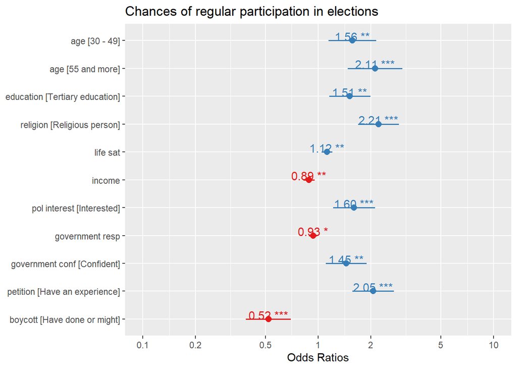

```r
plot_model(model_final, ci_method = "wald", show.values = TRUE,
           title = "Chances of regular participation in elections")
```

# Marginal effects - effect plots

1. Respondents in age of 15 -29 years old have the lowest expected probability of regular voting (0.29 vs 0.39 and 0.46). So, the difference between this group and group 55+ with the highest predicted probability of regular voting (0.46) is 17%.

```r
eff<-allEffects(model_final)
eff
```

```
##  model: vote ~ age + education + religion + life_sat + income + pol_interest +
##     government_resp + government_conf + petition + boycott
##
##  age effect
## age
##     15 - 29     30 - 49 55 and more
##   0.2910005   0.3910812   0.4639222
##
##  education effect
## education
## Secondary education or less          Tertiary education
##                   0.3239465                   0.4204393
##
##  religion effect
## religion
## Not a religious person       Religious person
##              0.3112804              0.4994444
##
##  life_sat effect
## life_sat
##         1         3         6         8        10
## 0.2466949 0.2915748 0.3670502 0.4215723 0.4780760
##
##  income effect
## income
##         1         3         6         8        10
## 0.5117669 0.4516803 0.3646299 0.3108207 0.2616818
##
##  pol_interest effect
## pol_interest
## Not interested     Interested
##      0.3421867      0.4545091
##
##  government_resp effect
## government_resp
##         1         3         6         8        10
## 0.4384068 0.4050529 0.3567056 0.3259598 0.2966420
##
##  government_conf effect
## government_conf
## Not confident     Confident
##     0.3460372     0.4333524
##
##  petition effect
## petition
##      No experience Have an experience
##          0.3040509          0.4728706
##
##  boycott effect
## boycott
##     Would never do Have done or might
##          0.4897826          0.3331088
```

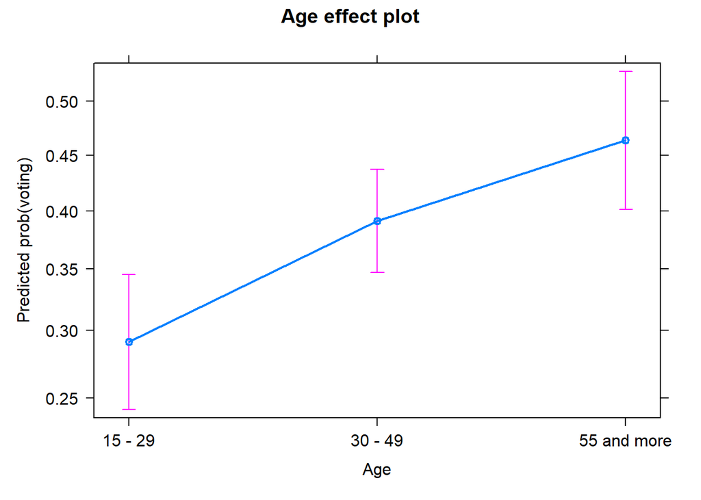

```r
plot(eff, 'age', ylab="Predicted prob(voting)", xlab = "Age",
     main = "Age effect plot")
```

2. Respondents with tertiary education have higher probability of regular voting than respondents with secondary education and lower (0.42 vs 0.32). So, the difference between these groups is 10%.

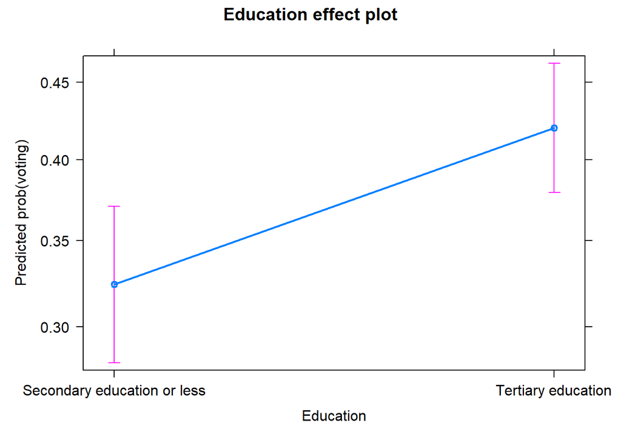

```r
plot(eff, 'education', ylab="Predicted prob(voting)", xlab = "Education",
     main = "Education effect plot")
```

3. Religious respondents have higher probability of regular voting than non-religious respondents (0.31 vs 0.50). So, the difference between these groups is 19%.

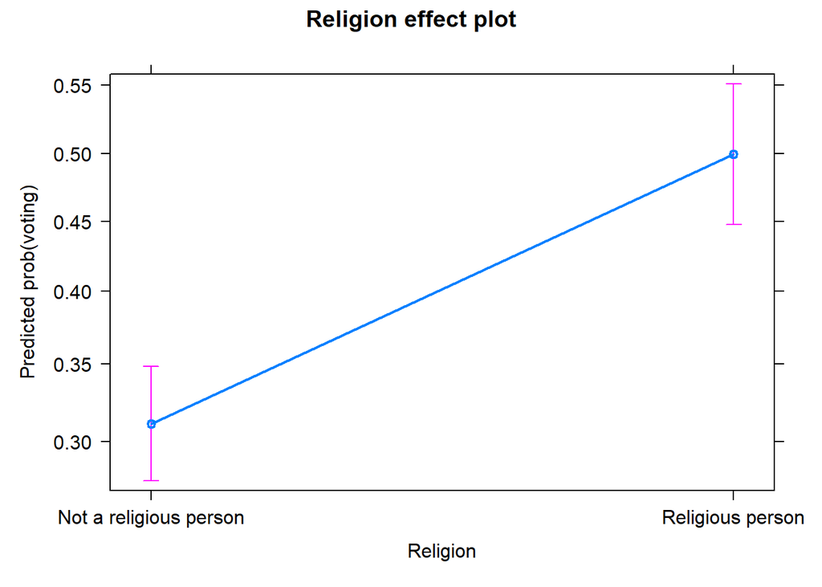

```r
plot(eff, 'religion', ylab="Predicted prob(voting)", xlab = "Religion",
     main = "Religion effect plot")
```

4. With the increasing of the level of life satisfaction predicted probability of regular voting is increasing: from 0.25 for the lowest level of life satisfaction (1), then 0.37 for an average level of life satisfaction (6), and 0.48 for the highest level of life satisfaction. So, the percentage difference between the lowest life satisfaction level and the highest one is 23%.

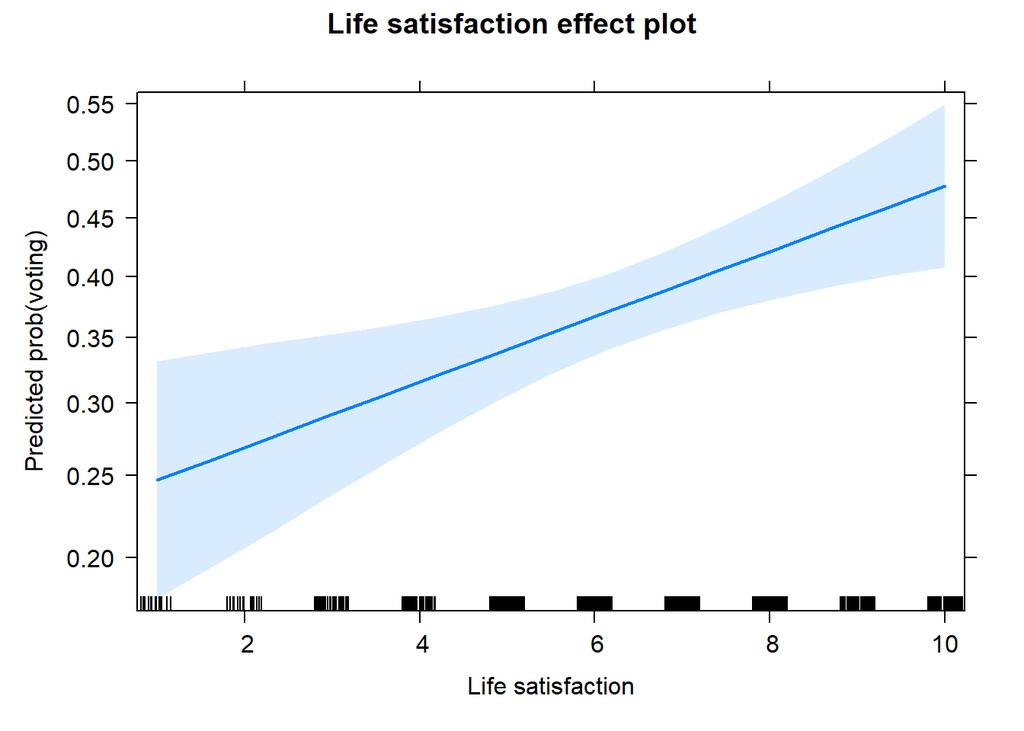

```r
plot(eff, 'life_sat', ylab="Predicted prob(voting)", xlab = "Life satisfaction",
     main = "Life satisfaction effect plot")
```

5. With the increasing of the level of income predicted probability of regular voting is decreasing: from 0.51 for the lowest level of income (1), then 0.36 for an average level of income (6), and 0.26 for the highest level of income. So, the percentage difference between the lowest income level and the highest one is 25%.

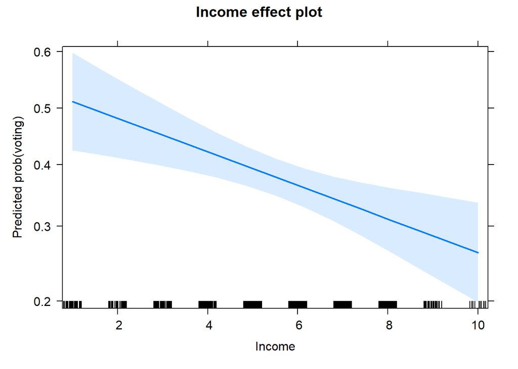

```r
plot(eff, 'income', ylab="Predicted prob(voting)", xlab = "Income",
     main = "Income effect plot")
```

6. Respondents who are interested in politics have higher probability of regular voting than those who are not interested in it (0.34 vs 0.45). So, the difference between these categories is 11%.

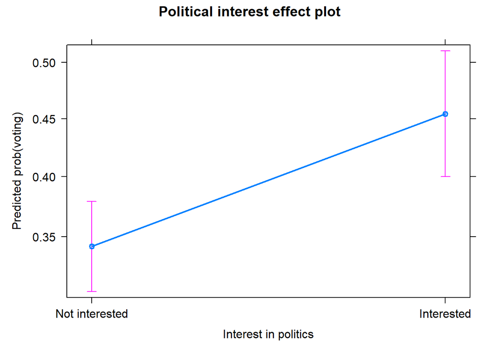

```r
plot(eff, 'pol_interest', ylab="Predicted prob(voting)", xlab = "Interest in politics",
     main = "Political interest effect plot")
```

7. With the increasing of the level of government responsibility probability of regular voting is decreasing: from 0.44 for the lowest level of government responsibility (1), then 0.36 for an average level of government responsibility (6), and 0.30 for the highest level of income. So, the percentage difference between the lowest government responsibility level and the highest one is 14%.

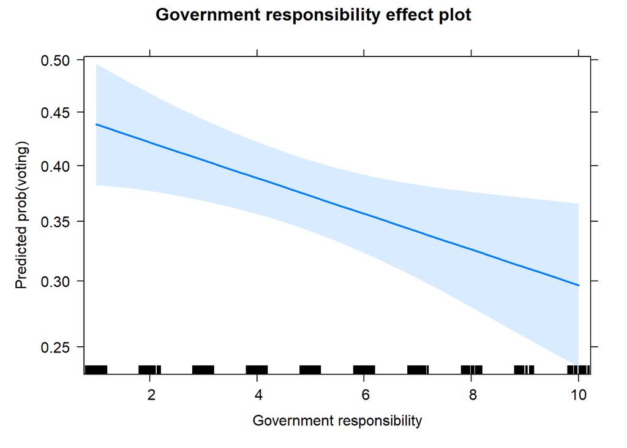

```r
plot(eff, 'government_resp', ylab="Predicted prob(voting)", xlab = "Government responsibility",
     main = "Government responsibility effect plot")
```

8. Respondents who are confident in government have higher probability of regular voting than those who are not confident in it (0.35 vs 0.43). So, the difference between these categories is 8%.

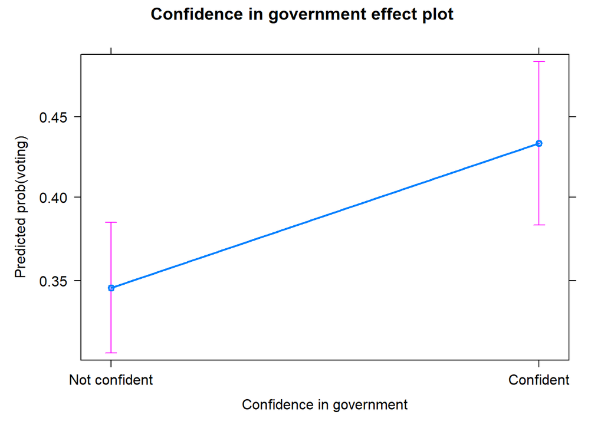

```r
plot(eff, 'government_conf', ylab="Predicted prob(voting)", xlab = "Confidence in government",
     main = "Confidence in government effect plot")
```

9. Respondents who have an experience in signing in petition have higher probability of regular voting than those who do not have it (0.47 vs 0.30). So, the difference between these categories is 17%.

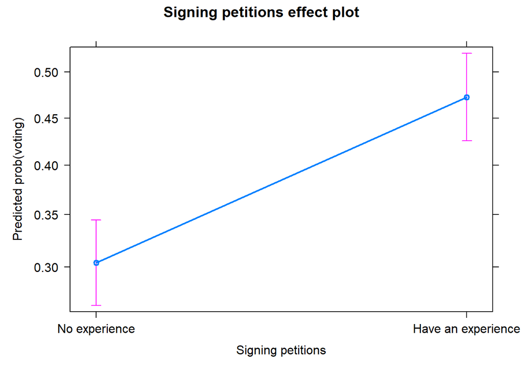

```r
plot(eff, 'petition', ylab="Predicted prob(voting)", xlab = "Signing petitions",
     main = "Signing petitions effect plot")
```

10. Respondents who would never join boycotts have higher probability of regular voting than those who have joined or might join boycotts (0.49 vs 0.33). So, the difference between these categories is 16%.

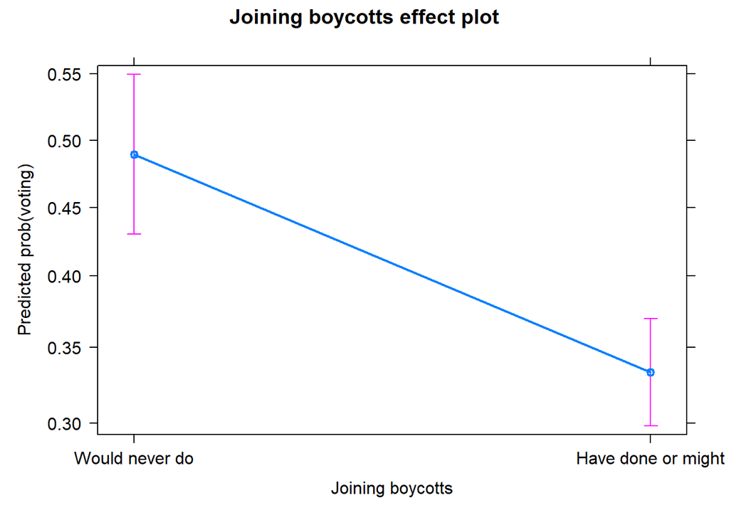

```r
plot(eff, 'boycott', ylab="Predicted prob(voting)", xlab = "Joining boycotts",
     main = "Joining boycotts effect plot")
```